# ANOVA test for tipologia_textual

Geiser C. Challco geiser@alumni.usp.br

- ANOVA: tipologia_textual ~ time
  - Data Preparation
  - Summary Statistics
  - ANOVA Computation
  - PairWise Computation
- ANOVA: tipologia_textual ~ time*gender + Error(id/time)
  - Data Preparation
    - Check assumptions: Identifying Outliers
    - Check assumptions: Normality Test
    - Summary Statistics
  - ANOVA Computation
  - ANOVA Computation after removing non.normal data
  - PairWise Computation
  - PairWise Computation after removing non.normal data
- ANOVA: tipologia_textual ~ time*localizacao + Error(id/time)
  - Data Preparation
    - Check assumptions: Identifying Outliers
    - Check assumptions: Normality Test
    - Summary Statistics
  - ANOVA Computation
  - ANOVA Computation after removing non.normal data
  - PairWise Computation
  - PairWise Computation after removing non.normal data
- ANOVA: tipologia_textual ~ time*regiao + Error(id/time)
  - Data Preparation
    - Check assumptions: Identifying Outliers
    - Check assumptions: Normality Test
    - Summary Statistics
  - ANOVA Computation
  - ANOVA Computation after removing non.normal data
  - PairWise Computation
- ANOVA: tipologia_textual ~ time*porte + Error(id/time)
  - Data Preparation
    - Check assumptions: Identifying Outliers
    - Check assumptions: Normality Test
    - Summary Statistics
  - ANOVA Computation
  - ANOVA Computation after removing non.normal data
  - PairWise Computation
  - PairWise Computation after removing non.normal data

```r
dat <- read_excel("../data/data.xlsx", sheet = "alunos_ef14")

escolas <- read_excel("../data/data.xlsx", sheet = "escolas")
edat <- merge(dat, escolas, by = "cod_escola", all.x = T)
```

# ANOVA: tipologia_textual ~ time

## Data Preparation

```r
data <- edat[,c("aluno_id","ciclo","tipologia_textual")]
data$ciclo <- factor(edat$ciclo, c("Primeiro Ciclo","Segundo Ciclo",
                                   "Terceiro Ciclo","Quarto Ciclo"))

wdat <- spread(data, ciclo, tipologia_textual)
wdat <- wdat[complete.cases(wdat),]
colnames(wdat) <- c("id","c1","c2","c3","c4")

ldat <- gather(wdat, key = time, value = tipologia_textual, c1, c2, c3, c4) %>%
  convert_as_factor(id, time)
ldat <- rshinystatistics::remove_group_data(ldat, "tipologia_textual", "time", n.limit = 30)
```

## Summary Statistics

```r
(sdat <- ldat %>% group_by(time) %>%
   get_summary_stats(tipologia_textual, type = "mean_sd"))
```

```
## # A tibble: 4 × 5
##   time  variable              n  mean    sd
##   <fct> <fct>             <dbl> <dbl> <dbl>
## 1 c1    tipologia_textual  1126  2.93 0.753
## 2 c2    tipologia_textual  1126  3.21 0.748
## 3 c3    tipologia_textual  1126  3.28 0.726
## 4 c4    tipologia_textual  1126  3.30 0.75
```

| time | variable | n | mean | sd |
| --- | --- | --- | --- | --- |
| c1 | tipologia_textual | 1126 | 2.929 | 0.753 |
| c2 | tipologia_textual | 1126 | 3.207 | 0.748 |
| c3 | tipologia_textual | 1126 | 3.275 | 0.726 |
| c4 | tipologia_textual | 1126 | 3.296 | 0.750 |

## ANOVA Computation

```r
(res.aov <- anova_test(ldat, dv = tipologia_textual, wid = id, within = time))
```

```
## ANOVA Table (type III tests)
##
## $ANOVA
##   Effect DFn  DFd      F        p p<.05   ges
## 1   time   3 3375 69.588 1.16e-43     * 0.037
##
## $`Mauchly's Test for Sphericity`
##   Effect     W       p p<.05
## 1   time 0.969 1.5e-06     *
##
## $`Sphericity Corrections`
##   Effect   GGe        DF[GG]    p[GG] p[GG]<.05   HFe        DF[HF]    p[HF]
## 1   time 0.979 2.94, 3304.22 8.33e-43         * 0.982 2.95, 3313.81 6.38e-43
##   p[HF]<.05
## 1         *
```

| Effect | DFn | DFd | F | p | p<.05 | ges |
| --- | --- | --- | --- | --- | --- | --- |
| time | 3 | 3375 | 69.588 | 0 | * | 0.037 |

| Effect | W | p | p<.05 |
| --- | --- | --- | --- |
| time | 0.969 | 0 | * |

| Effect | GGe | DF $$GG$$ | p $$GG$$ | p $$GG$$ <.05 | HFe | DF $$HF$$ | p $$HF$$ | p $$HF$$ <.05 |
| --- | --- | --- | --- | --- | --- | --- | --- | --- |
| time | 0.979 | 2.94, 3304.22 | 0 | * | 0.982 | 2.95, 3313.81 | 0 | * |

## PairWise Computation

```r
(pwc <- ldat %>% emmeans_test(tipologia_textual ~ time, detailed = T, p.adjust.method = "bonferroni"))
```

```
## # A tibble: 6 × 14
##   term  .y.    group1 group2 null.value estimate     se    df conf.low conf.high
## * <chr> <chr>  <chr>  <chr>       <dbl>    <dbl>  <dbl> <dbl>    <dbl>     <dbl>
## 1 time  tipol… c1     c2              0  -0.278  0.0314  4500  -0.339   -0.216
## 2 time  tipol… c1     c3              0  -0.346  0.0314  4500  -0.407   -0.284
## 3 time  tipol… c1     c4              0  -0.367  0.0314  4500  -0.429   -0.306
## 4 time  tipol… c2     c3              0  -0.0678 0.0314  4500  -0.129   -0.00630
## 5 time  tipol… c2     c4              0  -0.0891 0.0314  4500  -0.151   -0.0276
## 6 time  tipol… c3     c4              0  -0.0213 0.0314  4500  -0.0828   0.0402
## # ℹ 4 more variables: statistic <dbl>, p <dbl>, p.adj <dbl>, p.adj.signif <chr>
```

| term | .y. | group1 | group2 | null.value | estimate | se | df | conf.low | conf.high | statistic | p | p.adj | p.adj.signif |
| --- | --- | --- | --- | --- | --- | --- | --- | --- | --- | --- | --- | --- | --- |
| time | tipologia_textual | c1 | c2 | 0 | -0.278 | 0.031 | 4500 | -0.339 | -0.216 | -8.862 | 0.000 | 0.000 | **** |
| time | tipologia_textual | c1 | c3 | 0 | -0.346 | 0.031 | 4500 | -0.407 | -0.284 | -11.023 | 0.000 | 0.000 | **** |
| time | tipologia_textual | c1 | c4 | 0 | -0.367 | 0.031 | 4500 | -0.429 | -0.306 | -11.703 | 0.000 | 0.000 | **** |
| time | tipologia_textual | c2 | c3 | 0 | -0.068 | 0.031 | 4500 | -0.129 | -0.006 | -2.161 | 0.031 | 0.184 | ns |
| time | tipologia_textual | c2 | c4 | 0 | -0.089 | 0.031 | 4500 | -0.151 | -0.028 | -2.841 | 0.005 | 0.027 | * |
| time | tipologia_textual | c3 | c4 | 0 | -0.021 | 0.031 | 4500 | -0.083 | 0.040 | -0.680 | 0.497 | 1.000 | ns |

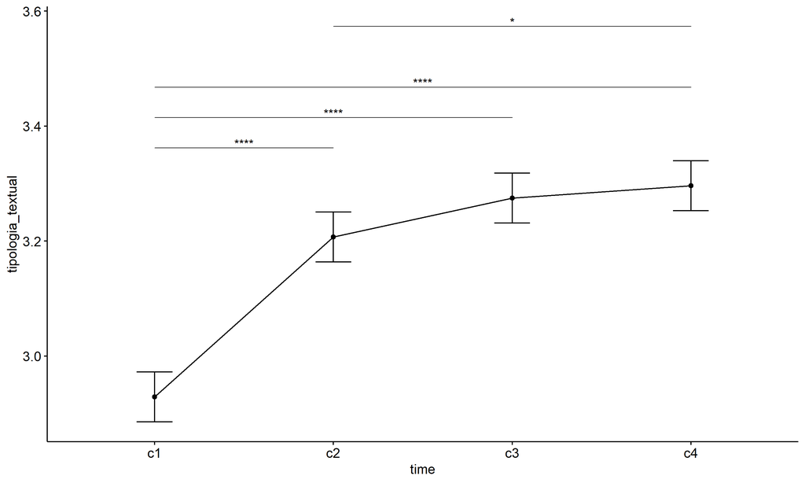

```r
pwc <- add_xy_position(pwc, x = "time", fun = "mean_se")
ggline(get_emmeans(pwc), x = "time", y = "emmean", ylab = "tipologia_textual") +
  geom_errorbar(aes(ymin = conf.low, ymax = conf.high), width = 0.2) +
  stat_pvalue_manual(pwc, hide.ns = T, tip.length = F)
```

# ANOVA: tipologia_textual ~ time*gender + Error(id/time)

## Data Preparation

```r
data <- edat[,c("aluno_id","gender","ciclo","tipologia_textual")]
data$ciclo <- factor(data$ciclo, c("Primeiro Ciclo","Segundo Ciclo",
                                   "Terceiro Ciclo","Quarto Ciclo"))

wdat <- spread(data, ciclo, tipologia_textual)
wdat <- wdat[complete.cases(wdat),]
colnames(wdat) <- c("id","gender","c1","c2","c3","c4")

ldat <- gather(wdat, key = time, value = tipologia_textual, c1, c2, c3, c4) %>%
  convert_as_factor(id, time)
ldat <- remove_group_data(ldat, "tipologia_textual", c("time", "gender"), n.limit = 30)
ldat$gender <- factor(ldat$gender, sort(unique(ldat$gender)))
```

### Check assumptions: Identifying Outliers

```r
outliers <- identify_outliers(group_by(ldat, time, gender), tipologia_textual)
(outliers <- outliers[outliers$is.extreme == T,])
```

```
## [1] gender            time              id                tipologia_textual
## [5] is.outlier        is.extreme
## <0 rows> (or 0-length row.names)
```

| gender | time | id | tipologia_textual | is.outlier | is.extreme |
| --- | --- | --- | --- | --- | --- |

### Check assumptions: Normality Test

```r
(normality.df <- normality.test.per.groups(ldat, "tipologia_textual", c("time", "gender")))
```

```
##                 var          variable time gender   n    skewness  kurtosis
## 1 tipologia_textual tipologia_textual   c1 Female 552  0.02095806 -1.301567
## 2 tipologia_textual tipologia_textual   c1   Male 513  0.17922232 -1.375926
## 3 tipologia_textual tipologia_textual   c2 Female 552 -0.45787903 -1.146322
## 4 tipologia_textual tipologia_textual   c2   Male 513 -0.30342098 -1.286263
## 5 tipologia_textual tipologia_textual   c3 Female 552 -0.51467689 -1.015697
## 6 tipologia_textual tipologia_textual   c3   Male 513 -0.49680897 -1.055991
## 7 tipologia_textual tipologia_textual   c4 Female 552 -0.55271772 -1.092799
## 8 tipologia_textual tipologia_textual   c4   Male 513 -0.58611661 -1.115590
##   symmetry statistic     method p p.signif normality
## 1      YES  847.8065 D'Agostino 0     ****         -
## 2      YES 2942.1023 D'Agostino 0     ****         -
## 3      YES  258.0519 D'Agostino 0     ****         -
## 4      YES  646.9158 D'Agostino 0     ****         -
## 5       NO  139.0058 D'Agostino 0     ****         -
## 6      YES  151.3571 D'Agostino 0     ****         -
## 7       NO  200.8667 D'Agostino 0     ****         -
## 8       NO  209.0475 D'Agostino 0     ****         -
```

| var | variable | time | gender | n | skewness | kurtosis | symmetry | statistic | method | p | p.signif | normality |
| --- | --- | --- | --- | --- | --- | --- | --- | --- | --- | --- | --- | --- |
| tipologia_textual | tipologia_textual | c1 | Female | 552 | 0.021 | -1.302 | YES | 847.806 | D’Agostino | 0 | **** | - |
| tipologia_textual | tipologia_textual | c1 | Male | 513 | 0.179 | -1.376 | YES | 2942.102 | D’Agostino | 0 | **** | - |
| tipologia_textual | tipologia_textual | c2 | Female | 552 | -0.458 | -1.146 | YES | 258.052 | D’Agostino | 0 | **** | - |
| tipologia_textual | tipologia_textual | c2 | Male | 513 | -0.303 | -1.286 | YES | 646.916 | D’Agostino | 0 | **** | - |
| tipologia_textual | tipologia_textual | c3 | Female | 552 | -0.515 | -1.016 | NO | 139.006 | D’Agostino | 0 | **** | - |
| tipologia_textual | tipologia_textual | c3 | Male | 513 | -0.497 | -1.056 | YES | 151.357 | D’Agostino | 0 | **** | - |
| tipologia_textual | tipologia_textual | c4 | Female | 552 | -0.553 | -1.093 | NO | 200.867 | D’Agostino | 0 | **** | - |
| tipologia_textual | tipologia_textual | c4 | Male | 513 | -0.586 | -1.116 | NO | 209.048 | D’Agostino | 0 | **** | - |

```r
(non.ids <- unique(do.call(
  c, lapply(which(normality.df$normality == 'NO'), FUN = function(i) {
  idx = which(ldat$time == normality.df$time[i] &
                ldat$gender == normality.df$gender[i])
  getNonNormal(ldat$"tipologia_textual"[idx], ldat$id[idx])
}))))
```

```r
if (length(non.ids) > 0)
  ldat2 <- ldat[!ldat$id %in% non.ids,]
```

### Summary Statistics

```r
(sdat <- ldat %>% group_by(time, gender) %>%
   get_summary_stats(tipologia_textual, type = "mean_sd"))
```

```
## # A tibble: 8 × 6
##   gender time  variable              n  mean    sd
##   <fct>  <fct> <fct>             <dbl> <dbl> <dbl>
## 1 Female c1    tipologia_textual   552  2.97 0.738
## 2 Male   c1    tipologia_textual   513  2.89 0.764
## 3 Female c2    tipologia_textual   552  3.25 0.743
## 4 Male   c2    tipologia_textual   513  3.15 0.759
## 5 Female c3    tipologia_textual   552  3.28 0.723
## 6 Male   c3    tipologia_textual   513  3.25 0.73
## 7 Female c4    tipologia_textual   552  3.28 0.748
## 8 Male   c4    tipologia_textual   513  3.30 0.761
```

| gender | time | variable | n | mean | sd |
| --- | --- | --- | --- | --- | --- |
| Female | c1 | tipologia_textual | 552 | 2.967 | 0.738 |
| Male | c1 | tipologia_textual | 513 | 2.894 | 0.764 |
| Female | c2 | tipologia_textual | 552 | 3.247 | 0.743 |
| Male | c2 | tipologia_textual | 513 | 3.151 | 0.759 |
| Female | c3 | tipologia_textual | 552 | 3.283 | 0.723 |
| Male | c3 | tipologia_textual | 513 | 3.250 | 0.730 |
| Female | c4 | tipologia_textual | 552 | 3.284 | 0.748 |
| Male | c4 | tipologia_textual | 513 | 3.297 | 0.761 |

```r
if (length(non.ids) > 0)
  (sdat <- ldat2 %>% group_by(time, gender) %>%
      get_summary_stats(tipologia_textual, type = "mean_sd"))
```

| gender | time | variable | n | mean | sd |
| --- | --- | --- | --- | --- | --- |
| Female | c1 | tipologia_textual | 552 | 2.967 | 0.738 |
| Male | c1 | tipologia_textual | 513 | 2.894 | 0.764 |
| Female | c2 | tipologia_textual | 552 | 3.247 | 0.743 |
| Male | c2 | tipologia_textual | 513 | 3.151 | 0.759 |
| Female | c3 | tipologia_textual | 552 | 3.283 | 0.723 |
| Male | c3 | tipologia_textual | 513 | 3.250 | 0.730 |
| Female | c4 | tipologia_textual | 552 | 3.284 | 0.748 |
| Male | c4 | tipologia_textual | 513 | 3.297 | 0.761 |

## ANOVA Computation

```r
(res.aov <- anova_test(ldat, dv = tipologia_textual, wid = id, between = gender, within = time))
```

```
## ANOVA Table (type III tests)
##
## $ANOVA
##        Effect DFn  DFd      F       p p<.05      ges
## 1      gender   1 1063  2.898 8.9e-02       0.001000
## 2        time   3 3189 62.194 4.5e-39     * 0.036000
## 3 gender:time   3 3189  1.339 2.6e-01       0.000792
##
## $`Mauchly's Test for Sphericity`
##        Effect     W        p p<.05
## 1        time 0.972 1.69e-05     *
## 2 gender:time 0.972 1.69e-05     *
##
## $`Sphericity Corrections`
##        Effect   GGe        DF[GG]    p[GG] p[GG]<.05   HFe        DF[HF]
## 1        time 0.981 2.94, 3128.25 2.21e-38         * 0.984 2.95, 3137.88
## 2 gender:time 0.981 2.94, 3128.25 2.60e-01           0.984 2.95, 3137.88
##      p[HF] p[HF]<.05
## 1 1.71e-38         *
## 2 2.60e-01
```

| Effect | DFn | DFd | F | p | p<.05 | ges |
| --- | --- | --- | --- | --- | --- | --- |
| gender | 1 | 1063 | 2.898 | 0.089 |  | 0.001 |
| time | 3 | 3189 | 62.194 | 0.000 | * | 0.036 |
| gender:time | 3 | 3189 | 1.339 | 0.260 |  | 0.001 |

| Effect | W | p | p<.05 |
| --- | --- | --- | --- |
| time | 0.972 | 0 | * |
| gender:time | 0.972 | 0 | * |

| Effect | GGe | DF $$GG$$ | p $$GG$$ | p $$GG$$ <.05 | HFe | DF $$HF$$ | p $$HF$$ | p $$HF$$ <.05 |
| --- | --- | --- | --- | --- | --- | --- | --- | --- |
| time | 0.981 | 2.94, 3128.25 | 0.00 | * | 0.984 | 2.95, 3137.88 | 0.00 | * |
| gender:time | 0.981 | 2.94, 3128.25 | 0.26 |  | 0.984 | 2.95, 3137.88 | 0.26 |  |

## ANOVA Computation after removing non.normal data

```r
if (length(non.ids) > 0)
  (res.aov2 <- anova_test(ldat2, dv = tipologia_textual, wid = id, between = gender , within = time))
```

## PairWise Computation

```r
(pwc <- ldat %>% group_by(time) %>%
   emmeans_test(tipologia_textual ~ gender, detailed = T, p.adjust.method = "bonferroni"))
```

```
## # A tibble: 4 × 15
##   time  term   .y.       group1 group2 null.value estimate     se    df conf.low
## * <fct> <chr>  <chr>     <chr>  <chr>       <dbl>    <dbl>  <dbl> <dbl>    <dbl>
## 1 c1    gender tipologi… Female Male            0   0.0736 0.0457  4252 -0.0160
## 2 c2    gender tipologi… Female Male            0   0.0965 0.0457  4252  0.00690
## 3 c3    gender tipologi… Female Male            0   0.0331 0.0457  4252 -0.0566
## 4 c4    gender tipologi… Female Male            0  -0.0138 0.0457  4252 -0.103
## # ℹ 5 more variables: conf.high <dbl>, statistic <dbl>, p <dbl>, p.adj <dbl>,
## #   p.adj.signif <chr>
```

| time | term | .y. | group1 | group2 | null.value | estimate | se | df | conf.low | conf.high | statistic | p | p.adj | p.adj.signif |
| --- | --- | --- | --- | --- | --- | --- | --- | --- | --- | --- | --- | --- | --- | --- |
| c1 | gender | tipologia_textual | Female | Male | 0 | 0.074 | 0.046 | 4252 | -0.016 | 0.163 | 1.610 | 0.107 | 0.107 | ns |
| c2 | gender | tipologia_textual | Female | Male | 0 | 0.097 | 0.046 | 4252 | 0.007 | 0.186 | 2.111 | 0.035 | 0.035 | * |
| c3 | gender | tipologia_textual | Female | Male | 0 | 0.033 | 0.046 | 4252 | -0.057 | 0.123 | 0.724 | 0.469 | 0.469 | ns |
| c4 | gender | tipologia_textual | Female | Male | 0 | -0.014 | 0.046 | 4252 | -0.103 | 0.076 | -0.301 | 0.764 | 0.764 | ns |

```r
(emms <- get_emmeans(pwc))
```

```
## # A tibble: 8 × 8
##   time  gender emmean     se    df conf.low conf.high method
##   <fct> <fct>   <dbl>  <dbl> <dbl>    <dbl>     <dbl> <chr>
## 1 c1    Female   2.97 0.0317  4252     2.91      3.03 Emmeans test
## 2 c1    Male     2.89 0.0329  4252     2.83      2.96 Emmeans test
## 3 c2    Female   3.25 0.0317  4252     3.18      3.31 Emmeans test
## 4 c2    Male     3.15 0.0329  4252     3.09      3.22 Emmeans test
## 5 c3    Female   3.28 0.0317  4252     3.22      3.34 Emmeans test
## 6 c3    Male     3.25 0.0329  4252     3.18      3.31 Emmeans test
## 7 c4    Female   3.28 0.0317  4252     3.22      3.35 Emmeans test
## 8 c4    Male     3.30 0.0329  4252     3.23      3.36 Emmeans test
```

| time | gender | emmean | se | df | conf.low | conf.high | method |
| --- | --- | --- | --- | --- | --- | --- | --- |
| c1 | Female | 2.967 | 0.032 | 4252 | 2.905 | 3.030 | Emmeans test |
| c1 | Male | 2.894 | 0.033 | 4252 | 2.829 | 2.958 | Emmeans test |
| c2 | Female | 3.247 | 0.032 | 4252 | 3.185 | 3.309 | Emmeans test |
| c2 | Male | 3.151 | 0.033 | 4252 | 3.086 | 3.215 | Emmeans test |
| c3 | Female | 3.283 | 0.032 | 4252 | 3.220 | 3.345 | Emmeans test |
| c3 | Male | 3.250 | 0.033 | 4252 | 3.185 | 3.314 | Emmeans test |
| c4 | Female | 3.284 | 0.032 | 4252 | 3.221 | 3.346 | Emmeans test |
| c4 | Male | 3.297 | 0.033 | 4252 | 3.233 | 3.362 | Emmeans test |

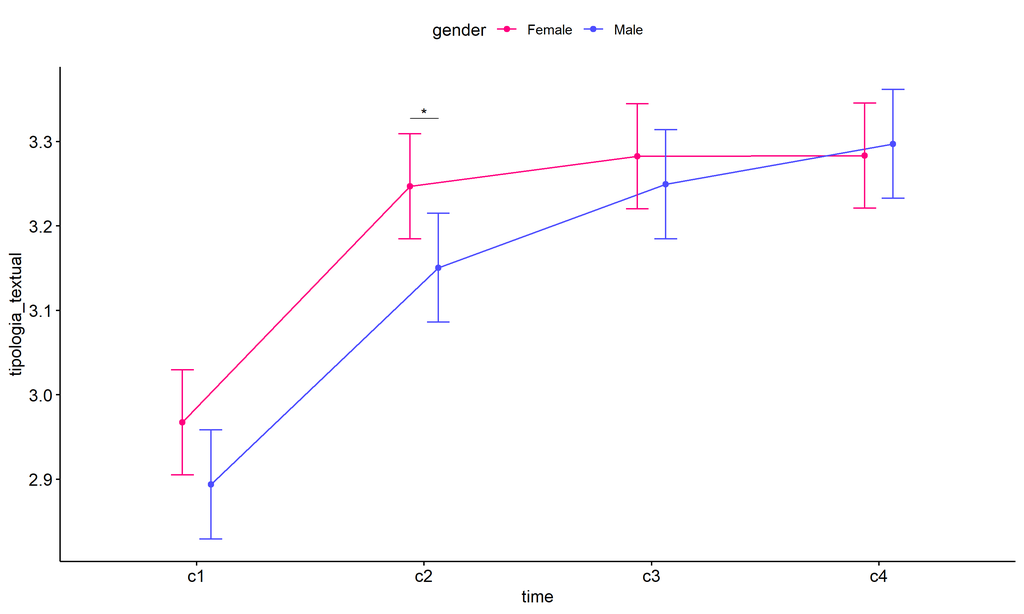

```r
pwc <- add_xy_position(pwc, x = "time", fun = "mean_se", dodge = 0.25)
pd <- position_dodge(width = 0.25)
ggline(emms, x = "time", y = "emmean", color = "gender",
       palette = c("#FF007F","#4D4DFF"),
       position = pd, ylab = "tipologia_textual") +
  geom_errorbar(aes(ymin = conf.low, ymax = conf.high, color = gender),
                position = pd, width = 0.2) +
  stat_pvalue_manual(pwc, hide.ns = T, tip.length = F, linetype = 1)
```

```r
(pwc <- ldat %>% group_by(gender) %>%
    emmeans_test(tipologia_textual ~ time, detailed = T, p.adjust.method = "bonferroni"))
```

```
## # A tibble: 12 × 15
##    gender term  .y.      group1 group2 null.value estimate     se    df conf.low
##  * <fct>  <chr> <chr>    <chr>  <chr>       <dbl>    <dbl>  <dbl> <dbl>    <dbl>
##  1 Female time  tipolog… c1     c2              0 -2.80e-1 0.0449  4252  -0.368
##  2 Female time  tipolog… c1     c3              0 -3.15e-1 0.0449  4252  -0.403
##  3 Female time  tipolog… c1     c4              0 -3.16e-1 0.0449  4252  -0.404
##  4 Female time  tipolog… c2     c3              0 -3.55e-2 0.0449  4252  -0.123
##  5 Female time  tipolog… c2     c4              0 -3.64e-2 0.0449  4252  -0.124
##  6 Female time  tipolog… c3     c4              0 -9.06e-4 0.0449  4252  -0.0889
##  7 Male   time  tipolog… c1     c2              0 -2.57e-1 0.0466  4252  -0.348
##  8 Male   time  tipolog… c1     c3              0 -3.56e-1 0.0466  4252  -0.447
##  9 Male   time  tipolog… c1     c4              0 -4.04e-1 0.0466  4252  -0.495
## 10 Male   time  tipolog… c2     c3              0 -9.89e-2 0.0466  4252  -0.190
## 11 Male   time  tipolog… c2     c4              0 -1.47e-1 0.0466  4252  -0.238
## 12 Male   time  tipolog… c3     c4              0 -4.78e-2 0.0466  4252  -0.139
## # ℹ 5 more variables: conf.high <dbl>, statistic <dbl>, p <dbl>, p.adj <dbl>,
## #   p.adj.signif <chr>
```

| gender | term | .y. | group1 | group2 | null.value | estimate | se | df | conf.low | conf.high | statistic | p | p.adj | p.adj.signif |
| --- | --- | --- | --- | --- | --- | --- | --- | --- | --- | --- | --- | --- | --- | --- |
| Female | time | tipologia_textual | c1 | c2 | 0 | -0.280 | 0.045 | 4252 | -0.368 | -0.192 | -6.233 | 0.000 | 0.000 | **** |
| Female | time | tipologia_textual | c1 | c3 | 0 | -0.315 | 0.045 | 4252 | -0.403 | -0.227 | -7.023 | 0.000 | 0.000 | **** |
| Female | time | tipologia_textual | c1 | c4 | 0 | -0.316 | 0.045 | 4252 | -0.404 | -0.228 | -7.044 | 0.000 | 0.000 | **** |
| Female | time | tipologia_textual | c2 | c3 | 0 | -0.035 | 0.045 | 4252 | -0.123 | 0.053 | -0.790 | 0.429 | 1.000 | ns |
| Female | time | tipologia_textual | c2 | c4 | 0 | -0.036 | 0.045 | 4252 | -0.124 | 0.052 | -0.811 | 0.418 | 1.000 | ns |
| Female | time | tipologia_textual | c3 | c4 | 0 | -0.001 | 0.045 | 4252 | -0.089 | 0.087 | -0.020 | 0.984 | 1.000 | ns |
| Male | time | tipologia_textual | c1 | c2 | 0 | -0.257 | 0.047 | 4252 | -0.348 | -0.166 | -5.516 | 0.000 | 0.000 | **** |
| Male | time | tipologia_textual | c1 | c3 | 0 | -0.356 | 0.047 | 4252 | -0.447 | -0.264 | -7.641 | 0.000 | 0.000 | **** |
| Male | time | tipologia_textual | c1 | c4 | 0 | -0.404 | 0.047 | 4252 | -0.495 | -0.312 | -8.667 | 0.000 | 0.000 | **** |
| Male | time | tipologia_textual | c2 | c3 | 0 | -0.099 | 0.047 | 4252 | -0.190 | -0.008 | -2.125 | 0.034 | 0.202 | ns |
| Male | time | tipologia_textual | c2 | c4 | 0 | -0.147 | 0.047 | 4252 | -0.238 | -0.055 | -3.151 | 0.002 | 0.010 | ** |
| Male | time | tipologia_textual | c3 | c4 | 0 | -0.048 | 0.047 | 4252 | -0.139 | 0.044 | -1.026 | 0.305 | 1.000 | ns |

```r
(emms <- get_emmeans(pwc))
```

```
## # A tibble: 8 × 8
##   gender time  emmean     se    df conf.low conf.high method
##   <fct>  <fct>  <dbl>  <dbl> <dbl>    <dbl>     <dbl> <chr>
## 1 Female c1      2.97 0.0317  4252     2.91      3.03 Emmeans test
## 2 Female c2      3.25 0.0317  4252     3.18      3.31 Emmeans test
## 3 Female c3      3.28 0.0317  4252     3.22      3.34 Emmeans test
## 4 Female c4      3.28 0.0317  4252     3.22      3.35 Emmeans test
## 5 Male   c1      2.89 0.0329  4252     2.83      2.96 Emmeans test
## 6 Male   c2      3.15 0.0329  4252     3.09      3.22 Emmeans test
## 7 Male   c3      3.25 0.0329  4252     3.18      3.31 Emmeans test
## 8 Male   c4      3.30 0.0329  4252     3.23      3.36 Emmeans test
```

| gender | time | emmean | se | df | conf.low | conf.high | method |
| --- | --- | --- | --- | --- | --- | --- | --- |
| Female | c1 | 2.967 | 0.032 | 4252 | 2.905 | 3.030 | Emmeans test |
| Female | c2 | 3.247 | 0.032 | 4252 | 3.185 | 3.309 | Emmeans test |
| Female | c3 | 3.283 | 0.032 | 4252 | 3.220 | 3.345 | Emmeans test |
| Female | c4 | 3.284 | 0.032 | 4252 | 3.221 | 3.346 | Emmeans test |
| Male | c1 | 2.894 | 0.033 | 4252 | 2.829 | 2.958 | Emmeans test |
| Male | c2 | 3.151 | 0.033 | 4252 | 3.086 | 3.215 | Emmeans test |
| Male | c3 | 3.250 | 0.033 | 4252 | 3.185 | 3.314 | Emmeans test |
| Male | c4 | 3.297 | 0.033 | 4252 | 3.233 | 3.362 | Emmeans test |

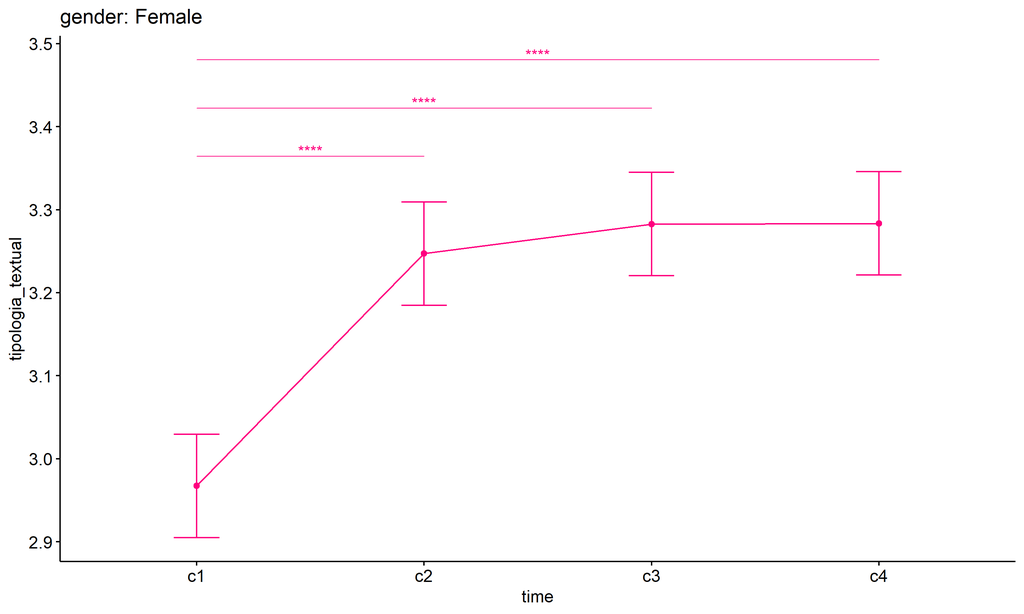

```r
emms.gg <- emms[which(emms$gender == "Female"),]
if (nrow(emms.gg) > 0)
  ggline(emms.gg, x = "time", y = "emmean", color = "#FF007F", ylab = "tipologia_textual") +
    geom_errorbar(aes(ymin = conf.low, ymax = conf.high),
                  width = 0.2, color = "#FF007F") +
    stat_pvalue_manual(
      add_xy_position(pwc[which(pwc$gender == "Female"),],
                      x = "time", fun = "mean_se"),
      hide.ns = T, color = "#FF007F", tip.length = F) +
    labs(title = "gender: Female")+
    theme(legend.text = element_blank())
```

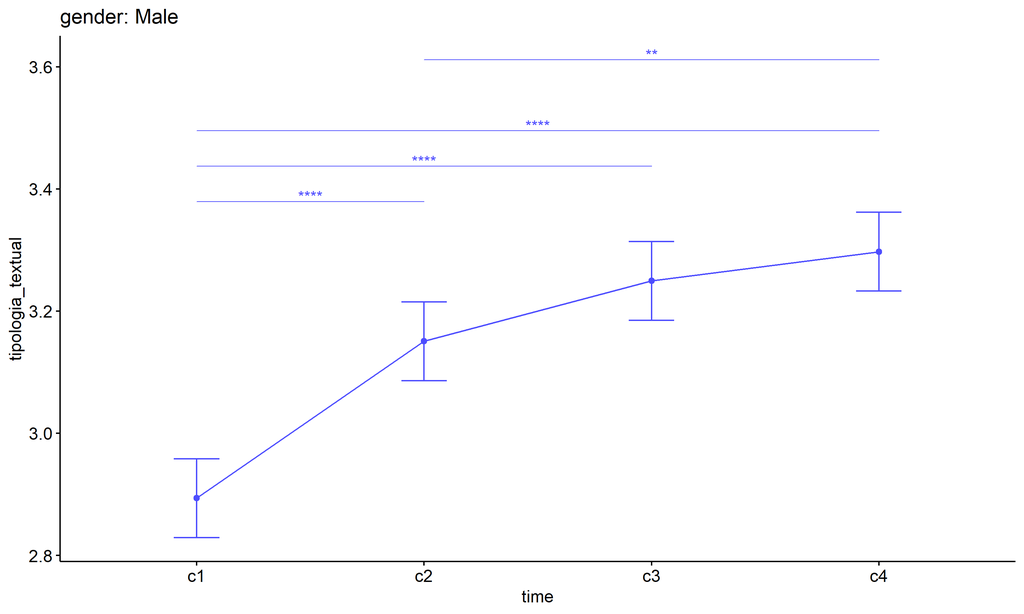

```r
emms.gg <- emms[which(emms$gender == "Male"),]
if (nrow(emms.gg) > 0)
  ggline(emms.gg, x = "time", y = "emmean", color = "#4D4DFF", ylab = "tipologia_textual") +
    geom_errorbar(aes(ymin = conf.low, ymax = conf.high),
                  width = 0.2, color = "#4D4DFF") +
    stat_pvalue_manual(
      add_xy_position(pwc[which(pwc$gender == "Male"),],
                      x = "time", fun = "mean_se"),
      hide.ns = T, color = "#4D4DFF", tip.length = F) +
    labs(title = "gender: Male")+
    theme(legend.text = element_blank())
```

## PairWise Computation after removing non.normal data

```r
if (length(non.ids) > 0)
  (pwc2 <- ldat2 %>% group_by(time) %>%
     emmeans_test(tipologia_textual ~ gender, detailed = T, p.adjust.method = "bonferroni"))
```

```r
if (length(non.ids) > 0)
  (emms2 <- get_emmeans(pwc2))
```

```r
if (length(non.ids) > 0) {
  pwc2 <- add_xy_position(pwc2, x = "time", fun = "mean_se", dodge = 0.25)
  pd2 <- position_dodge(width = 0.25)

  ggline(emms2, x = "time", y = "emmean", color = "gender",
         palette = c("#FF007F","#4D4DFF"),
         position = pd, ylab = "tipologia_textual") +
    geom_errorbar(aes(ymin = conf.low, ymax = conf.high, color = gender),
                position = pd, width = 0.2) +
    stat_pvalue_manual(pwc2, hide.ns = T, tip.length = F, linetype = 1)
}
```

```r
if (length(non.ids) > 0)
  (pwc2 <- ldat2 %>% group_by(gender) %>%
     emmeans_test(tipologia_textual ~ time, detailed = T, p.adjust.method = "bonferroni"))
```

```r
if (length(non.ids) > 0)
  (emms2 <- get_emmeans(pwc2))
```

```r
if (length(non.ids) > 0) {
  emms.gg <- emms2[which(emms2$gender == "Female"),]
  if (nrow(emms.gg) > 0)
    ggline(emms.gg, x = "time", y = "emmean", color = "#FF007F", ylab = "tipologia_textual") +
    geom_errorbar(aes(ymin = conf.low, ymax = conf.high),
                  width = 0.2, color = "#FF007F") +
    stat_pvalue_manual(
      add_xy_position(pwc[which(pwc$gender == "Female"),],
                      x = "time", fun = "mean_se"),
      hide.ns = T, color = "#FF007F", tip.length = F) +
    labs(title = "gender: Female") +
    theme(legend.text = element_blank())
}
```

```r
if (length(non.ids) > 0) {
  emms.gg <- emms2[which(emms2$gender == "Male"),]
  if (nrow(emms.gg) > 0)
    ggline(emms.gg, x = "time", y = "emmean", color = "#4D4DFF", ylab = "tipologia_textual") +
    geom_errorbar(aes(ymin = conf.low, ymax = conf.high),
                  width = 0.2, color = "#4D4DFF") +
    stat_pvalue_manual(
      add_xy_position(pwc[which(pwc$gender == "Male"),],
                      x = "time", fun = "mean_se"),
      hide.ns = T, color = "#4D4DFF", tip.length = F) +
    labs(title = "gender: Male") +
    theme(legend.text = element_blank())
}
```

# ANOVA: tipologia_textual ~ time*localizacao + Error(id/time)

## Data Preparation

```r
data <- edat[,c("aluno_id","localizacao","ciclo","tipologia_textual")]
data$ciclo <- factor(data$ciclo, c("Primeiro Ciclo","Segundo Ciclo",
                                   "Terceiro Ciclo","Quarto Ciclo"))

wdat <- spread(data, ciclo, tipologia_textual)
wdat <- wdat[complete.cases(wdat),]
colnames(wdat) <- c("id","localizacao","c1","c2","c3","c4")

ldat <- gather(wdat, key = time, value = tipologia_textual, c1, c2, c3, c4) %>%
  convert_as_factor(id, time)
ldat <- remove_group_data(ldat, "tipologia_textual", c("time", "localizacao"), n.limit = 30)
ldat$localizacao <- factor(ldat$localizacao, sort(unique(ldat$localizacao)))
```

### Check assumptions: Identifying Outliers

```r
outliers <- identify_outliers(group_by(ldat, time, localizacao), tipologia_textual)
(outliers <- outliers[outliers$is.extreme == T,])
```

```
## [1] localizacao       time              id                tipologia_textual
## [5] is.outlier        is.extreme
## <0 rows> (or 0-length row.names)
```

| localizacao | time | id | tipologia_textual | is.outlier | is.extreme |
| --- | --- | --- | --- | --- | --- |

### Check assumptions: Normality Test

```r
(normality.df <- normality.test.per.groups(ldat, "tipologia_textual", c("time", "localizacao")))
```

```
##                 var          variable time localizacao   n    skewness
## 1 tipologia_textual tipologia_textual   c1       Rural 181  0.10760091
## 2 tipologia_textual tipologia_textual   c1      Urbana 945  0.09866504
## 3 tipologia_textual tipologia_textual   c2       Rural 181 -0.32031667
## 4 tipologia_textual tipologia_textual   c2      Urbana 945 -0.40729724
## 5 tipologia_textual tipologia_textual   c3       Rural 181 -0.86672058
## 6 tipologia_textual tipologia_textual   c3      Urbana 945 -0.46191266
## 7 tipologia_textual tipologia_textual   c4       Rural 181 -0.62407072
## 8 tipologia_textual tipologia_textual   c4      Urbana 945 -0.56560073
##     kurtosis symmetry   statistic     method            p p.signif normality
## 1 -1.5186364      YES 18207.62967 D'Agostino 0.000000e+00     ****        QQ
## 2 -1.3160354      YES  2465.01953 D'Agostino 0.000000e+00     ****         -
## 3 -1.1978609      YES    74.28087 D'Agostino 1.110223e-16     ****        QQ
## 4 -1.1972298      YES   677.95628 D'Agostino 0.000000e+00     ****         -
## 5 -0.4515101       NO    20.81163 D'Agostino 3.025598e-05      ***        QQ
## 6 -1.0867043      YES   346.06049 D'Agostino 0.000000e+00     ****         -
## 7 -0.9084726       NO    29.03530 D'Agostino 4.955237e-07     ****        QQ
## 8 -1.1158756       NO   419.50955 D'Agostino 0.000000e+00     ****         -
```

| var | variable | time | localizacao | n | skewness | kurtosis | symmetry | statistic | method | p | p.signif | normality |
| --- | --- | --- | --- | --- | --- | --- | --- | --- | --- | --- | --- | --- |
| tipologia_textual | tipologia_textual | c1 | Rural | 181 | 0.108 | -1.519 | YES | 18207.630 | D’Agostino | 0 | **** | QQ |
| tipologia_textual | tipologia_textual | c1 | Urbana | 945 | 0.099 | -1.316 | YES | 2465.020 | D’Agostino | 0 | **** | - |
| tipologia_textual | tipologia_textual | c2 | Rural | 181 | -0.320 | -1.198 | YES | 74.281 | D’Agostino | 0 | **** | QQ |
| tipologia_textual | tipologia_textual | c2 | Urbana | 945 | -0.407 | -1.197 | YES | 677.956 | D’Agostino | 0 | **** | - |
| tipologia_textual | tipologia_textual | c3 | Rural | 181 | -0.867 | -0.452 | NO | 20.812 | D’Agostino | 0 | *** | QQ |
| tipologia_textual | tipologia_textual | c3 | Urbana | 945 | -0.462 | -1.087 | YES | 346.060 | D’Agostino | 0 | **** | - |
| tipologia_textual | tipologia_textual | c4 | Rural | 181 | -0.624 | -0.908 | NO | 29.035 | D’Agostino | 0 | **** | QQ |
| tipologia_textual | tipologia_textual | c4 | Urbana | 945 | -0.566 | -1.116 | NO | 419.510 | D’Agostino | 0 | **** | - |

```r
(non.ids <- unique(do.call(
  c, lapply(which(normality.df$normality == 'NO'), FUN = function(i) {
  idx = which(ldat$time == normality.df$time[i] &
                ldat$localizacao == normality.df$localizacao[i])
  getNonNormal(ldat$"tipologia_textual"[idx], ldat$id[idx])
}))))
```

```r
if (length(non.ids) > 0)
  ldat2 <- ldat[!ldat$id %in% non.ids,]
```

### Summary Statistics

```r
(sdat <- ldat %>% group_by(time, localizacao) %>%
   get_summary_stats(tipologia_textual, type = "mean_sd"))
```

```
## # A tibble: 8 × 6
##   localizacao time  variable              n  mean    sd
##   <fct>       <fct> <fct>             <dbl> <dbl> <dbl>
## 1 Rural       c1    tipologia_textual   181  2.94 0.795
## 2 Urbana      c1    tipologia_textual   945  2.93 0.745
## 3 Rural       c2    tipologia_textual   181  3.18 0.74
## 4 Urbana      c2    tipologia_textual   945  3.21 0.75
## 5 Rural       c3    tipologia_textual   181  3.42 0.674
## 6 Urbana      c3    tipologia_textual   945  3.25 0.733
## 7 Rural       c4    tipologia_textual   181  3.34 0.706
## 8 Urbana      c4    tipologia_textual   945  3.29 0.758
```

| localizacao | time | variable | n | mean | sd |
| --- | --- | --- | --- | --- | --- |
| Rural | c1 | tipologia_textual | 181 | 2.939 | 0.795 |
| Urbana | c1 | tipologia_textual | 945 | 2.927 | 0.745 |
| Rural | c2 | tipologia_textual | 181 | 3.182 | 0.740 |
| Urbana | c2 | tipologia_textual | 945 | 3.212 | 0.750 |
| Rural | c3 | tipologia_textual | 181 | 3.425 | 0.674 |
| Urbana | c3 | tipologia_textual | 945 | 3.246 | 0.733 |
| Rural | c4 | tipologia_textual | 181 | 3.345 | 0.706 |
| Urbana | c4 | tipologia_textual | 945 | 3.287 | 0.758 |

```r
if (length(non.ids) > 0)
  (sdat <- ldat2 %>% group_by(time, localizacao) %>%
      get_summary_stats(tipologia_textual, type = "mean_sd"))
```

| localizacao | time | variable | n | mean | sd |
| --- | --- | --- | --- | --- | --- |
| Rural | c1 | tipologia_textual | 181 | 2.939 | 0.795 |
| Urbana | c1 | tipologia_textual | 945 | 2.927 | 0.745 |
| Rural | c2 | tipologia_textual | 181 | 3.182 | 0.740 |
| Urbana | c2 | tipologia_textual | 945 | 3.212 | 0.750 |
| Rural | c3 | tipologia_textual | 181 | 3.425 | 0.674 |
| Urbana | c3 | tipologia_textual | 945 | 3.246 | 0.733 |
| Rural | c4 | tipologia_textual | 181 | 3.345 | 0.706 |
| Urbana | c4 | tipologia_textual | 945 | 3.287 | 0.758 |

## ANOVA Computation

```r
(res.aov <- anova_test(ldat, dv = tipologia_textual, wid = id, between = localizacao, within = time))
```

```
## ANOVA Table (type III tests)
##
## $ANOVA
##             Effect DFn  DFd      F        p p<.05      ges
## 1      localizacao   1 1124  2.249 1.34e-01       0.000742
## 2             time   3 3372 44.967 1.73e-28     * 0.025000
## 3 localizacao:time   3 3372  2.670 4.60e-02     * 0.001000
##
## $`Mauchly's Test for Sphericity`
##             Effect     W        p p<.05
## 1             time 0.969 1.32e-06     *
## 2 localizacao:time 0.969 1.32e-06     *
##
## $`Sphericity Corrections`
##             Effect   GGe        DF[GG]    p[GG] p[GG]<.05   HFe        DF[HF]
## 1             time 0.979 2.94, 3300.43 6.12e-28         * 0.982 2.94, 3310.01
## 2 localizacao:time 0.979 2.94, 3300.43 4.70e-02         * 0.982 2.94, 3310.01
##      p[HF] p[HF]<.05
## 1 5.17e-28         *
## 2 4.70e-02         *
```

| Effect | DFn | DFd | F | p | p<.05 | ges |
| --- | --- | --- | --- | --- | --- | --- |
| localizacao | 1 | 1124 | 2.249 | 0.134 |  | 0.001 |
| time | 3 | 3372 | 44.967 | 0.000 | * | 0.025 |
| localizacao:time | 3 | 3372 | 2.670 | 0.046 | * | 0.001 |

| Effect | W | p | p<.05 |
| --- | --- | --- | --- |
| time | 0.969 | 0 | * |
| localizacao:time | 0.969 | 0 | * |

| Effect | GGe | DF $$GG$$ | p $$GG$$ | p $$GG$$ <.05 | HFe | DF $$HF$$ | p $$HF$$ | p $$HF$$ <.05 |
| --- | --- | --- | --- | --- | --- | --- | --- | --- |
| time | 0.979 | 2.94, 3300.43 | 0.000 | * | 0.982 | 2.94, 3310.01 | 0.000 | * |
| localizacao:time | 0.979 | 2.94, 3300.43 | 0.047 | * | 0.982 | 2.94, 3310.01 | 0.047 | * |

## ANOVA Computation after removing non.normal data

```r
if (length(non.ids) > 0)
  (res.aov2 <- anova_test(ldat2, dv = tipologia_textual, wid = id, between = localizacao , within = time))
```

## PairWise Computation

```r
(pwc <- ldat %>% group_by(time) %>%
   emmeans_test(tipologia_textual ~ localizacao, detailed = T, p.adjust.method = "bonferroni"))
```

```
## # A tibble: 4 × 15
##   time  term       .y.   group1 group2 null.value estimate     se    df conf.low
## * <fct> <chr>      <chr> <chr>  <chr>       <dbl>    <dbl>  <dbl> <dbl>    <dbl>
## 1 c1    localizac… tipo… Rural  Urbana          0   0.0121 0.0603  4496  -0.106
## 2 c2    localizac… tipo… Rural  Urbana          0  -0.0295 0.0603  4496  -0.148
## 3 c3    localizac… tipo… Rural  Urbana          0   0.179  0.0603  4496   0.0611
## 4 c4    localizac… tipo… Rural  Urbana          0   0.0585 0.0603  4496  -0.0598
## # ℹ 5 more variables: conf.high <dbl>, statistic <dbl>, p <dbl>, p.adj <dbl>,
## #   p.adj.signif <chr>
```

| time | term | .y. | group1 | group2 | null.value | estimate | se | df | conf.low | conf.high | statistic | p | p.adj | p.adj.signif |
| --- | --- | --- | --- | --- | --- | --- | --- | --- | --- | --- | --- | --- | --- | --- |
| c1 | localizacao | tipologia_textual | Rural | Urbana | 0 | 0.012 | 0.06 | 4496 | -0.106 | 0.130 | 0.200 | 0.842 | 0.842 | ns |
| c2 | localizacao | tipologia_textual | Rural | Urbana | 0 | -0.029 | 0.06 | 4496 | -0.148 | 0.089 | -0.489 | 0.625 | 0.625 | ns |
| c3 | localizacao | tipologia_textual | Rural | Urbana | 0 | 0.179 | 0.06 | 4496 | 0.061 | 0.298 | 2.973 | 0.003 | 0.003 | ** |
| c4 | localizacao | tipologia_textual | Rural | Urbana | 0 | 0.059 | 0.06 | 4496 | -0.060 | 0.177 | 0.970 | 0.332 | 0.332 | ns |

```r
(emms <- get_emmeans(pwc))
```

```
## # A tibble: 8 × 8
##   time  localizacao emmean     se    df conf.low conf.high method
##   <fct> <fct>        <dbl>  <dbl> <dbl>    <dbl>     <dbl> <chr>
## 1 c1    Rural         2.94 0.0553  4496     2.83      3.05 Emmeans test
## 2 c1    Urbana        2.93 0.0242  4496     2.88      2.97 Emmeans test
## 3 c2    Rural         3.18 0.0553  4496     3.07      3.29 Emmeans test
## 4 c2    Urbana        3.21 0.0242  4496     3.16      3.26 Emmeans test
## 5 c3    Rural         3.43 0.0553  4496     3.32      3.53 Emmeans test
## 6 c3    Urbana        3.25 0.0242  4496     3.20      3.29 Emmeans test
## 7 c4    Rural         3.35 0.0553  4496     3.24      3.45 Emmeans test
## 8 c4    Urbana        3.29 0.0242  4496     3.24      3.33 Emmeans test
```

| time | localizacao | emmean | se | df | conf.low | conf.high | method |
| --- | --- | --- | --- | --- | --- | --- | --- |
| c1 | Rural | 2.939 | 0.055 | 4496 | 2.831 | 3.048 | Emmeans test |
| c1 | Urbana | 2.927 | 0.024 | 4496 | 2.880 | 2.975 | Emmeans test |
| c2 | Rural | 3.182 | 0.055 | 4496 | 3.074 | 3.291 | Emmeans test |
| c2 | Urbana | 3.212 | 0.024 | 4496 | 3.164 | 3.259 | Emmeans test |
| c3 | Rural | 3.425 | 0.055 | 4496 | 3.317 | 3.534 | Emmeans test |
| c3 | Urbana | 3.246 | 0.024 | 4496 | 3.199 | 3.293 | Emmeans test |
| c4 | Rural | 3.345 | 0.055 | 4496 | 3.237 | 3.454 | Emmeans test |
| c4 | Urbana | 3.287 | 0.024 | 4496 | 3.239 | 3.334 | Emmeans test |

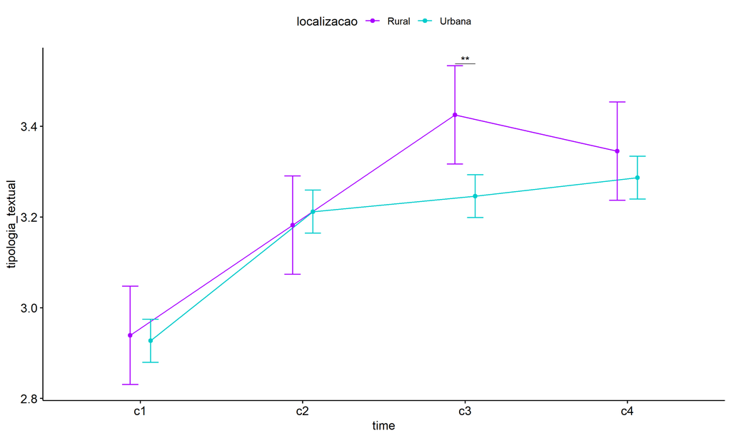

```r
pwc <- add_xy_position(pwc, x = "time", fun = "mean_se", dodge = 0.25)
pd <- position_dodge(width = 0.25)
ggline(emms, x = "time", y = "emmean", color = "localizacao",
       palette = c("#AA00FF","#00CCCC"),
       position = pd, ylab = "tipologia_textual") +
  geom_errorbar(aes(ymin = conf.low, ymax = conf.high, color = localizacao),
                position = pd, width = 0.2) +
  stat_pvalue_manual(pwc, hide.ns = T, tip.length = F, linetype = 1)
```

```r
(pwc <- ldat %>% group_by(localizacao) %>%
    emmeans_test(tipologia_textual ~ time, detailed = T, p.adjust.method = "bonferroni"))
```

```
## # A tibble: 12 × 15
##    localizacao term  .y.          group1 group2 null.value estimate     se    df
##  * <fct>       <chr> <chr>        <chr>  <chr>       <dbl>    <dbl>  <dbl> <dbl>
##  1 Rural       time  tipologia_t… c1     c2              0  -0.243  0.0782  4496
##  2 Rural       time  tipologia_t… c1     c3              0  -0.486  0.0782  4496
##  3 Rural       time  tipologia_t… c1     c4              0  -0.406  0.0782  4496
##  4 Rural       time  tipologia_t… c2     c3              0  -0.243  0.0782  4496
##  5 Rural       time  tipologia_t… c2     c4              0  -0.163  0.0782  4496
##  6 Rural       time  tipologia_t… c3     c4              0   0.0801 0.0782  4496
##  7 Urbana      time  tipologia_t… c1     c2              0  -0.285  0.0342  4496
##  8 Urbana      time  tipologia_t… c1     c3              0  -0.319  0.0342  4496
##  9 Urbana      time  tipologia_t… c1     c4              0  -0.360  0.0342  4496
## 10 Urbana      time  tipologia_t… c2     c3              0  -0.0342 0.0342  4496
## 11 Urbana      time  tipologia_t… c2     c4              0  -0.0750 0.0342  4496
## 12 Urbana      time  tipologia_t… c3     c4              0  -0.0407 0.0342  4496
## # ℹ 6 more variables: conf.low <dbl>, conf.high <dbl>, statistic <dbl>,
## #   p <dbl>, p.adj <dbl>, p.adj.signif <chr>
```

| localizacao | term | .y. | group1 | group2 | null.value | estimate | se | df | conf.low | conf.high | statistic | p | p.adj | p.adj.signif |
| --- | --- | --- | --- | --- | --- | --- | --- | --- | --- | --- | --- | --- | --- | --- |
| Rural | time | tipologia_textual | c1 | c2 | 0 | -0.243 | 0.078 | 4496 | -0.396 | -0.090 | -3.109 | 0.002 | 0.011 | * |
| Rural | time | tipologia_textual | c1 | c3 | 0 | -0.486 | 0.078 | 4496 | -0.639 | -0.333 | -6.219 | 0.000 | 0.000 | **** |
| Rural | time | tipologia_textual | c1 | c4 | 0 | -0.406 | 0.078 | 4496 | -0.559 | -0.253 | -5.194 | 0.000 | 0.000 | **** |
| Rural | time | tipologia_textual | c2 | c3 | 0 | -0.243 | 0.078 | 4496 | -0.396 | -0.090 | -3.109 | 0.002 | 0.011 | * |
| Rural | time | tipologia_textual | c2 | c4 | 0 | -0.163 | 0.078 | 4496 | -0.316 | -0.010 | -2.085 | 0.037 | 0.223 | ns |
| Rural | time | tipologia_textual | c3 | c4 | 0 | 0.080 | 0.078 | 4496 | -0.073 | 0.233 | 1.025 | 0.306 | 1.000 | ns |
| Urbana | time | tipologia_textual | c1 | c2 | 0 | -0.285 | 0.034 | 4496 | -0.352 | -0.218 | -8.319 | 0.000 | 0.000 | **** |
| Urbana | time | tipologia_textual | c1 | c3 | 0 | -0.319 | 0.034 | 4496 | -0.386 | -0.252 | -9.319 | 0.000 | 0.000 | **** |
| Urbana | time | tipologia_textual | c1 | c4 | 0 | -0.360 | 0.034 | 4496 | -0.427 | -0.293 | -10.510 | 0.000 | 0.000 | **** |
| Urbana | time | tipologia_textual | c2 | c3 | 0 | -0.034 | 0.034 | 4496 | -0.101 | 0.033 | -1.000 | 0.317 | 1.000 | ns |
| Urbana | time | tipologia_textual | c2 | c4 | 0 | -0.075 | 0.034 | 4496 | -0.142 | -0.008 | -2.191 | 0.029 | 0.171 | ns |
| Urbana | time | tipologia_textual | c3 | c4 | 0 | -0.041 | 0.034 | 4496 | -0.108 | 0.026 | -1.191 | 0.234 | 1.000 | ns |

```r
(emms <- get_emmeans(pwc))
```

```
## # A tibble: 8 × 8
##   localizacao time  emmean     se    df conf.low conf.high method
##   <fct>       <fct>  <dbl>  <dbl> <dbl>    <dbl>     <dbl> <chr>
## 1 Rural       c1      2.94 0.0553  4496     2.83      3.05 Emmeans test
## 2 Rural       c2      3.18 0.0553  4496     3.07      3.29 Emmeans test
## 3 Rural       c3      3.43 0.0553  4496     3.32      3.53 Emmeans test
## 4 Rural       c4      3.35 0.0553  4496     3.24      3.45 Emmeans test
## 5 Urbana      c1      2.93 0.0242  4496     2.88      2.97 Emmeans test
## 6 Urbana      c2      3.21 0.0242  4496     3.16      3.26 Emmeans test
## 7 Urbana      c3      3.25 0.0242  4496     3.20      3.29 Emmeans test
## 8 Urbana      c4      3.29 0.0242  4496     3.24      3.33 Emmeans test
```

| localizacao | time | emmean | se | df | conf.low | conf.high | method |
| --- | --- | --- | --- | --- | --- | --- | --- |
| Rural | c1 | 2.939 | 0.055 | 4496 | 2.831 | 3.048 | Emmeans test |
| Rural | c2 | 3.182 | 0.055 | 4496 | 3.074 | 3.291 | Emmeans test |
| Rural | c3 | 3.425 | 0.055 | 4496 | 3.317 | 3.534 | Emmeans test |
| Rural | c4 | 3.345 | 0.055 | 4496 | 3.237 | 3.454 | Emmeans test |
| Urbana | c1 | 2.927 | 0.024 | 4496 | 2.880 | 2.975 | Emmeans test |
| Urbana | c2 | 3.212 | 0.024 | 4496 | 3.164 | 3.259 | Emmeans test |
| Urbana | c3 | 3.246 | 0.024 | 4496 | 3.199 | 3.293 | Emmeans test |
| Urbana | c4 | 3.287 | 0.024 | 4496 | 3.239 | 3.334 | Emmeans test |

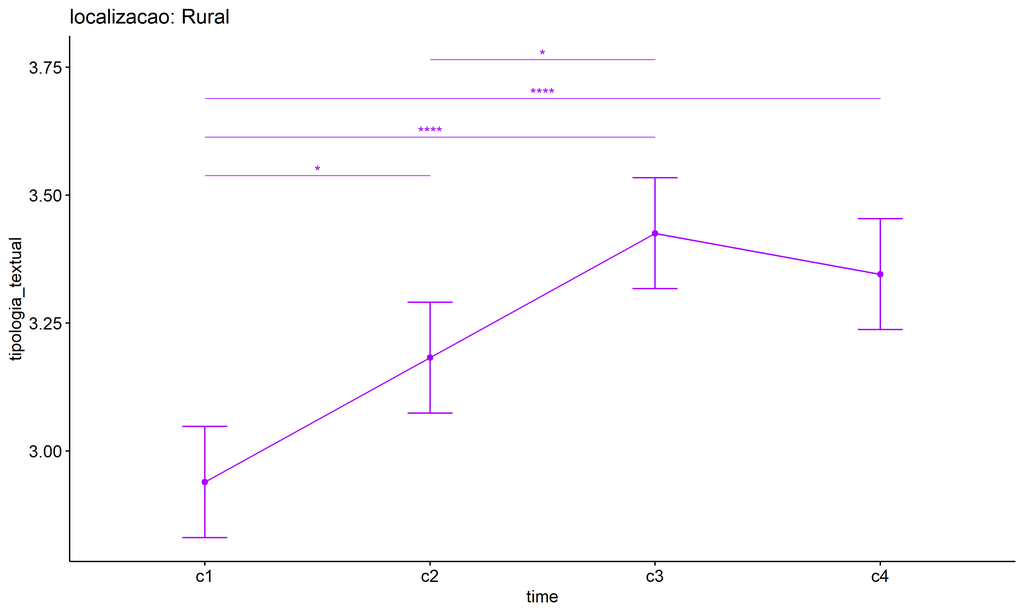

```r
emms.gg <- emms[which(emms$localizacao == "Rural"),]
if (nrow(emms.gg) > 0)
  ggline(emms.gg, x = "time", y = "emmean", color = "#AA00FF", ylab = "tipologia_textual") +
    geom_errorbar(aes(ymin = conf.low, ymax = conf.high),
                  width = 0.2, color = "#AA00FF") +
    stat_pvalue_manual(
      add_xy_position(pwc[which(pwc$localizacao == "Rural"),],
                      x = "time", fun = "mean_se"),
      hide.ns = T, color = "#AA00FF", tip.length = F) +
    labs(title = "localizacao: Rural")+
    theme(legend.text = element_blank())
```

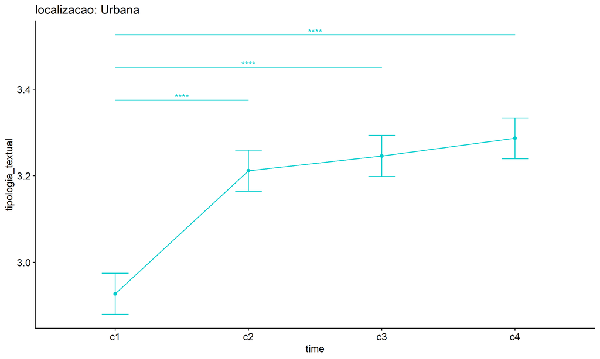

```r
emms.gg <- emms[which(emms$localizacao == "Urbana"),]
if (nrow(emms.gg) > 0)
  ggline(emms.gg, x = "time", y = "emmean", color = "#00CCCC", ylab = "tipologia_textual") +
    geom_errorbar(aes(ymin = conf.low, ymax = conf.high),
                  width = 0.2, color = "#00CCCC") +
    stat_pvalue_manual(
      add_xy_position(pwc[which(pwc$localizacao == "Urbana"),],
                      x = "time", fun = "mean_se"),
      hide.ns = T, color = "#00CCCC", tip.length = F) +
    labs(title = "localizacao: Urbana")+
    theme(legend.text = element_blank())
```

## PairWise Computation after removing non.normal data

```r
if (length(non.ids) > 0)
  (pwc2 <- ldat2 %>% group_by(time) %>%
     emmeans_test(tipologia_textual ~ localizacao, detailed = T, p.adjust.method = "bonferroni"))
```

```r
if (length(non.ids) > 0)
  (emms2 <- get_emmeans(pwc2))
```

```r
if (length(non.ids) > 0) {
  pwc2 <- add_xy_position(pwc2, x = "time", fun = "mean_se", dodge = 0.25)
  pd2 <- position_dodge(width = 0.25)

  ggline(emms2, x = "time", y = "emmean", color = "localizacao",
         palette = c("#AA00FF","#00CCCC"),
         position = pd, ylab = "tipologia_textual") +
    geom_errorbar(aes(ymin = conf.low, ymax = conf.high, color = localizacao),
                position = pd, width = 0.2) +
    stat_pvalue_manual(pwc2, hide.ns = T, tip.length = F, linetype = 1)
}
```

```r
if (length(non.ids) > 0)
  (pwc2 <- ldat2 %>% group_by(localizacao) %>%
     emmeans_test(tipologia_textual ~ time, detailed = T, p.adjust.method = "bonferroni"))
```

```r
if (length(non.ids) > 0)
  (emms2 <- get_emmeans(pwc2))
```

```r
if (length(non.ids) > 0) {
  emms.gg <- emms2[which(emms2$localizacao == "Rural"),]
  if (nrow(emms.gg) > 0)
    ggline(emms.gg, x = "time", y = "emmean", color = "#AA00FF", ylab = "tipologia_textual") +
    geom_errorbar(aes(ymin = conf.low, ymax = conf.high),
                  width = 0.2, color = "#AA00FF") +
    stat_pvalue_manual(
      add_xy_position(pwc[which(pwc$localizacao == "Rural"),],
                      x = "time", fun = "mean_se"),
      hide.ns = T, color = "#AA00FF", tip.length = F) +
    labs(title = "localizacao: Rural") +
    theme(legend.text = element_blank())
}
```

```r
if (length(non.ids) > 0) {
  emms.gg <- emms2[which(emms2$localizacao == "Urbana"),]
  if (nrow(emms.gg) > 0)
    ggline(emms.gg, x = "time", y = "emmean", color = "#00CCCC", ylab = "tipologia_textual") +
    geom_errorbar(aes(ymin = conf.low, ymax = conf.high),
                  width = 0.2, color = "#00CCCC") +
    stat_pvalue_manual(
      add_xy_position(pwc[which(pwc$localizacao == "Urbana"),],
                      x = "time", fun = "mean_se"),
      hide.ns = T, color = "#00CCCC", tip.length = F) +
    labs(title = "localizacao: Urbana") +
    theme(legend.text = element_blank())
}
```

# ANOVA: tipologia_textual ~ time*regiao + Error(id/time)

## Data Preparation

```r
data <- edat[,c("aluno_id","regiao","ciclo","tipologia_textual")]
data$ciclo <- factor(data$ciclo, c("Primeiro Ciclo","Segundo Ciclo",
                                   "Terceiro Ciclo","Quarto Ciclo"))

wdat <- spread(data, ciclo, tipologia_textual)
wdat <- wdat[complete.cases(wdat),]
colnames(wdat) <- c("id","regiao","c1","c2","c3","c4")

ldat <- gather(wdat, key = time, value = tipologia_textual, c1, c2, c3, c4) %>%
  convert_as_factor(id, time)
ldat <- remove_group_data(ldat, "tipologia_textual", c("time", "regiao"), n.limit = 30)
ldat$regiao <- factor(ldat$regiao, sort(unique(ldat$regiao)))
```

### Check assumptions: Identifying Outliers

```r
outliers <- identify_outliers(group_by(ldat, time, regiao), tipologia_textual)
(outliers <- outliers[outliers$is.extreme == T,])
```

```
## # A tibble: 0 × 6
## # ℹ 6 variables: regiao <fct>, time <fct>, id <fct>, tipologia_textual <dbl>,
## #   is.outlier <lgl>, is.extreme <lgl>
```

| regiao | time | id | tipologia_textual | is.outlier | is.extreme |
| --- | --- | --- | --- | --- | --- |

### Check assumptions: Normality Test

```r
(normality.df <- normality.test.per.groups(ldat, "tipologia_textual", c("time", "regiao")))
```

```
##                  var          variable time       regiao   n    skewness
## 1  tipologia_textual tipologia_textual   c1 Centro-Oeste  48 -0.03774909
## 2  tipologia_textual tipologia_textual   c1     Nordeste 545  0.02907756
## 3  tipologia_textual tipologia_textual   c1        Norte  78  0.84117902
## 4  tipologia_textual tipologia_textual   c1      Sudeste 393  0.11351654
## 5  tipologia_textual tipologia_textual   c1          Sul  62 -0.11545806
## 6  tipologia_textual tipologia_textual   c2 Centro-Oeste  48 -0.55131673
## 7  tipologia_textual tipologia_textual   c2     Nordeste 545 -0.37552844
## 8  tipologia_textual tipologia_textual   c2        Norte  78 -0.24361949
## 9  tipologia_textual tipologia_textual   c2      Sudeste 393 -0.43499598
## 10 tipologia_textual tipologia_textual   c2          Sul  62 -0.34747430
## 11 tipologia_textual tipologia_textual   c3 Centro-Oeste  48 -0.50206365
## 12 tipologia_textual tipologia_textual   c3     Nordeste 545 -0.51647612
## 13 tipologia_textual tipologia_textual   c3        Norte  78 -0.38683423
## 14 tipologia_textual tipologia_textual   c3      Sudeste 393 -0.51824854
```

[output cut: 48 more lines]

| var | variable | time | regiao | n | skewness | kurtosis | symmetry | statistic | method | p | p.signif | normality |
| --- | --- | --- | --- | --- | --- | --- | --- | --- | --- | --- | --- | --- |
| tipologia_textual | tipologia_textual | c1 | Centro-Oeste | 48 | -0.038 | -0.882 | YES | 0.897 | Shapiro-Wilk | 0.000 | *** | NO |
| tipologia_textual | tipologia_textual | c1 | Nordeste | 545 | 0.029 | -1.352 | YES | 1825.950 | D’Agostino | 0.000 | **** | - |
| tipologia_textual | tipologia_textual | c1 | Norte | 78 | 0.841 | -0.517 | NO | 9.489 | D’Agostino | 0.009 | ** | NO |
| tipologia_textual | tipologia_textual | c1 | Sudeste | 393 | 0.114 | -1.406 | YES | 3587.414 | D’Agostino | 0.000 | **** | - |
| tipologia_textual | tipologia_textual | c1 | Sul | 62 | -0.115 | -1.296 | YES | 19.467 | D’Agostino | 0.000 | **** | NO |
| tipologia_textual | tipologia_textual | c2 | Centro-Oeste | 48 | -0.551 | -0.641 | NO | 0.868 | Shapiro-Wilk | 0.000 | **** | NO |
| tipologia_textual | tipologia_textual | c2 | Nordeste | 545 | -0.376 | -1.194 | YES | 335.246 | D’Agostino | 0.000 | **** | - |
| tipologia_textual | tipologia_textual | c2 | Norte | 78 | -0.244 | -1.230 | YES | 22.460 | D’Agostino | 0.000 | **** | NO |
| tipologia_textual | tipologia_textual | c2 | Sudeste | 393 | -0.435 | -1.197 | YES | 225.570 | D’Agostino | 0.000 | **** | - |
| tipologia_textual | tipologia_textual | c2 | Sul | 62 | -0.347 | -1.570 | YES | 77.193 | D’Agostino | 0.000 | **** | NO |
| tipologia_textual | tipologia_textual | c3 | Centro-Oeste | 48 | -0.502 | -0.907 | NO | 0.857 | Shapiro-Wilk | 0.000 | **** | NO |
| tipologia_textual | tipologia_textual | c3 | Nordeste | 545 | -0.516 | -0.981 | NO | 118.927 | D’Agostino | 0.000 | **** | - |
| tipologia_textual | tipologia_textual | c3 | Norte | 78 | -0.387 | -1.045 | YES | 11.918 | D’Agostino | 0.003 | ** | NO |
| tipologia_textual | tipologia_textual | c3 | Sudeste | 393 | -0.518 | -1.094 | NO | 132.901 | D’Agostino | 0.000 | **** | - |
| tipologia_textual | tipologia_textual | c3 | Sul | 62 | -0.889 | -0.833 | NO | 10.699 | D’Agostino | 0.005 | ** | NO |
| tipologia_textual | tipologia_textual | c4 | Centro-Oeste | 48 | -0.715 | -1.209 | NO | 0.730 | Shapiro-Wilk | 0.000 | **** | NO |
| tipologia_textual | tipologia_textual | c4 | Nordeste | 545 | -0.453 | -1.170 | YES | 292.242 | D’Agostino | 0.000 | **** | - |
| tipologia_textual | tipologia_textual | c4 | Norte | 78 | -0.368 | -1.310 | YES | 33.065 | D’Agostino | 0.000 | **** | NO |
| tipologia_textual | tipologia_textual | c4 | Sudeste | 393 | -0.678 | -0.987 | NO | 94.060 | D’Agostino | 0.000 | **** | - |
| tipologia_textual | tipologia_textual | c4 | Sul | 62 | -1.205 | 0.272 | NO | 14.094 | D’Agostino | 0.001 | *** | NO |

```r
(non.ids <- unique(do.call(
  c, lapply(which(normality.df$normality == 'NO'), FUN = function(i) {
  idx = which(ldat$time == normality.df$time[i] &
                ldat$regiao == normality.df$regiao[i])
  getNonNormal(ldat$"tipologia_textual"[idx], ldat$id[idx])
}))))
```

```
##   [1] "ZwZKuoXF7JaYzVxPoHvk" "9jd1C85ixCoJf3EINYfx" "atydp19vM0PjiOQCWemR"
##   [4] "XPDsLJmk5xRPBBQTOEFf" "vvjX443BD3mkWYYMec2R" "edONhkMBY1DIsXNuuodO"
##   [7] "oB5KNHL8aUZyGZK3jNIP" "0HZYO8qt2G3sqgoXITwe" "LSOWrW4dOhXZ9uMW17va"
##  [10] "q1RelulkOweB4lCMWfxy" "ygFJxqySABX8ax57ihIq" "18EWxrJZtjBVpzckkv21"
##  [13] "3fTmP8cTTJq8WUIEU0Xl" "3mBgwnK6Vvt3dkhVOTAf" "q2OHBM4WxXWQPFhPS0zC"
##  [16] "8p6QYQYkfhR3QOACXZvj" "WshMGLj49S97LCd6BetO" "i5Gd55pjKNa1DpzdbUJf"
##  [19] "vSolOA78V6l7oYJ1h4LA" "AIyVJKr8sUUkQIogcjw3" "aOGxFSPrreKjHqmQIKKA"
##  [22] "fCbOJlY4s8hncfy108S2" "qbpdhqIdqf7n3lmU2n4I" "IJtLVa8jEy3VAWIMlskm"
##  [25] "gzBUwnjjYHnioTnd4stC" "H5F4r5nnGQTG1FzfyxrY" "0JP4C8o7n2HYsnPDx4qx"
##  [28] "0rFiZU3E0rQ5w337VW1f" "2Mvl0siGmos3P6uCJoI6" "6G6n552emVnSHTVpUDh7"
##  [31] "6ICRgE0rvAmB7lOuAmyQ" "7hA9dTcMihNepxAII972" "84eMLEkOxEAhysQoqAVy"
##  [34] "9ZgjvRy0pzK2NOHnuf9Q" "adLuVVMS0UYoOiJolMNI" "AypBhseeTW0r2FXDFr9W"
##  [37] "bOhetFcZCcckN4VKJMtL" "C7qUNZkE9MPTJTXcamV9" "D2pOFdXWqe1zu0vNxz89"
##  [40] "fEYVARleb30C16nBEYEI" "fG86EI7DcC48zeKBVr8r" "GGTfV3iZASa8xWD4aoiL"
##  [43] "goC0bbJnYpzgY6ol6rsz" "oB0FOxzsLr7yBiRPTQ2A" "0anDuhDMTormRx17gQtL"
```

[output cut: 38 more lines]

```r
if (length(non.ids) > 0)
  ldat2 <- ldat[!ldat$id %in% non.ids,]
```

### Summary Statistics

```r
(sdat <- ldat %>% group_by(time, regiao) %>%
   get_summary_stats(tipologia_textual, type = "mean_sd"))
```

```
## # A tibble: 20 × 6
##    regiao       time  variable              n  mean    sd
##    <fct>        <fct> <fct>             <dbl> <dbl> <dbl>
##  1 Centro-Oeste c1    tipologia_textual    48  2.96 0.626
##  2 Nordeste     c1    tipologia_textual   545  2.97 0.753
##  3 Norte        c1    tipologia_textual    78  2.56 0.668
##  4 Sudeste      c1    tipologia_textual   393  2.92 0.769
##  5 Sul          c1    tipologia_textual    62  3.02 0.735
##  6 Centro-Oeste c2    tipologia_textual    48  3.22 0.652
##  7 Nordeste     c2    tipologia_textual   545  3.2  0.744
##  8 Norte        c2    tipologia_textual    78  3.14 0.734
##  9 Sudeste      c2    tipologia_textual   393  3.23 0.752
## 10 Sul          c2    tipologia_textual    62  3.19 0.852
## 11 Centro-Oeste c3    tipologia_textual    48  3.17 0.687
## 12 Nordeste     c3    tipologia_textual   545  3.28 0.711
## 13 Norte        c3    tipologia_textual    78  3.15 0.712
## 14 Sudeste      c3    tipologia_textual   393  3.28 0.744
## 15 Sul          c3    tipologia_textual    62  3.43 0.773
## 16 Centro-Oeste c4    tipologia_textual    48  3.33 0.827
## 17 Nordeste     c4    tipologia_textual   545  3.24 0.747
## 18 Norte        c4    tipologia_textual    78  3.17 0.759
## 19 Sudeste      c4    tipologia_textual   393  3.34 0.752
## 20 Sul          c4    tipologia_textual    62  3.64 0.567
```

| regiao | time | variable | n | mean | sd |
| --- | --- | --- | --- | --- | --- |
| Centro-Oeste | c1 | tipologia_textual | 48 | 2.958 | 0.626 |
| Nordeste | c1 | tipologia_textual | 545 | 2.974 | 0.753 |
| Norte | c1 | tipologia_textual | 78 | 2.560 | 0.668 |
| Sudeste | c1 | tipologia_textual | 393 | 2.922 | 0.769 |
| Sul | c1 | tipologia_textual | 62 | 3.016 | 0.735 |
| Centro-Oeste | c2 | tipologia_textual | 48 | 3.222 | 0.652 |
| Nordeste | c2 | tipologia_textual | 545 | 3.200 | 0.744 |
| Norte | c2 | tipologia_textual | 78 | 3.141 | 0.734 |
| Sudeste | c2 | tipologia_textual | 393 | 3.232 | 0.752 |
| Sul | c2 | tipologia_textual | 62 | 3.187 | 0.852 |
| Centro-Oeste | c3 | tipologia_textual | 48 | 3.167 | 0.687 |
| Nordeste | c3 | tipologia_textual | 545 | 3.282 | 0.711 |
| Norte | c3 | tipologia_textual | 78 | 3.147 | 0.712 |
| Sudeste | c3 | tipologia_textual | 393 | 3.280 | 0.744 |
| Sul | c3 | tipologia_textual | 62 | 3.427 | 0.773 |
| Centro-Oeste | c4 | tipologia_textual | 48 | 3.333 | 0.827 |
| Nordeste | c4 | tipologia_textual | 545 | 3.240 | 0.747 |
| Norte | c4 | tipologia_textual | 78 | 3.173 | 0.759 |
| Sudeste | c4 | tipologia_textual | 393 | 3.340 | 0.752 |
| Sul | c4 | tipologia_textual | 62 | 3.637 | 0.567 |

```r
if (length(non.ids) > 0)
  (sdat <- ldat2 %>% group_by(time, regiao) %>%
      get_summary_stats(tipologia_textual, type = "mean_sd"))
```

```
## # A tibble: 16 × 6
##    regiao       time  variable              n  mean     sd
##    <fct>        <fct> <fct>             <dbl> <dbl>  <dbl>
##  1 Centro-Oeste c1    tipologia_textual     1  2    NA
##  2 Nordeste     c1    tipologia_textual   545  2.97  0.753
##  3 Norte        c1    tipologia_textual    29  2.71  0.526
##  4 Sudeste      c1    tipologia_textual   393  2.92  0.769
##  5 Centro-Oeste c2    tipologia_textual     1  3    NA
##  6 Nordeste     c2    tipologia_textual   545  3.2   0.744
##  7 Norte        c2    tipologia_textual    29  2.88  0.703
##  8 Sudeste      c2    tipologia_textual   393  3.23  0.752
##  9 Centro-Oeste c3    tipologia_textual     1  3    NA
## 10 Nordeste     c3    tipologia_textual   545  3.28  0.711
## 11 Norte        c3    tipologia_textual    29  3.21  0.662
## 12 Sudeste      c3    tipologia_textual   393  3.28  0.744
## 13 Centro-Oeste c4    tipologia_textual     1  3.5  NA
## 14 Nordeste     c4    tipologia_textual   545  3.24  0.747
## 15 Norte        c4    tipologia_textual    29  3.05  0.686
## 16 Sudeste      c4    tipologia_textual   393  3.34  0.752
```

| regiao | time | variable | n | mean | sd |
| --- | --- | --- | --- | --- | --- |
| Centro-Oeste | c1 | tipologia_textual | 1 | 2.000 | NA |
| Nordeste | c1 | tipologia_textual | 545 | 2.974 | 0.753 |
| Norte | c1 | tipologia_textual | 29 | 2.707 | 0.526 |
| Sudeste | c1 | tipologia_textual | 393 | 2.922 | 0.769 |
| Centro-Oeste | c2 | tipologia_textual | 1 | 3.000 | NA |
| Nordeste | c2 | tipologia_textual | 545 | 3.200 | 0.744 |
| Norte | c2 | tipologia_textual | 29 | 2.879 | 0.703 |
| Sudeste | c2 | tipologia_textual | 393 | 3.232 | 0.752 |
| Centro-Oeste | c3 | tipologia_textual | 1 | 3.000 | NA |
| Nordeste | c3 | tipologia_textual | 545 | 3.282 | 0.711 |
| Norte | c3 | tipologia_textual | 29 | 3.207 | 0.662 |
| Sudeste | c3 | tipologia_textual | 393 | 3.280 | 0.744 |
| Centro-Oeste | c4 | tipologia_textual | 1 | 3.500 | NA |
| Nordeste | c4 | tipologia_textual | 545 | 3.240 | 0.747 |
| Norte | c4 | tipologia_textual | 29 | 3.052 | 0.686 |
| Sudeste | c4 | tipologia_textual | 393 | 3.340 | 0.752 |

## ANOVA Computation

```r
(res.aov <- anova_test(ldat, dv = tipologia_textual, wid = id, between = regiao, within = time))
```

```
## ANOVA Table (type III tests)
##
## $ANOVA
##        Effect DFn  DFd      F        p p<.05   ges
## 1      regiao   4 1121  4.464 1.00e-03     * 0.006
## 2        time   3 3363 39.904 2.48e-25     * 0.022
## 3 regiao:time  12 3363  2.275 7.00e-03     * 0.005
##
## $`Mauchly's Test for Sphericity`
##        Effect    W        p p<.05
## 1        time 0.97 2.34e-06     *
## 2 regiao:time 0.97 2.34e-06     *
##
## $`Sphericity Corrections`
##        Effect  GGe         DF[GG]    p[GG] p[GG]<.05   HFe         DF[HF]
## 1        time 0.98  2.94, 3294.42 7.19e-25         * 0.982  2.95, 3304.02
## 2 regiao:time 0.98 11.76, 3294.42 8.00e-03         * 0.982 11.79, 3304.02
##     p[HF] p[HF]<.05
## 1 6.2e-25         *
## 2 8.0e-03         *
```

| Effect | DFn | DFd | F | p | p<.05 | ges |
| --- | --- | --- | --- | --- | --- | --- |
| regiao | 4 | 1121 | 4.464 | 0.001 | * | 0.006 |
| time | 3 | 3363 | 39.904 | 0.000 | * | 0.022 |
| regiao:time | 12 | 3363 | 2.275 | 0.007 | * | 0.005 |

| Effect | W | p | p<.05 |
| --- | --- | --- | --- |
| time | 0.97 | 0 | * |
| regiao:time | 0.97 | 0 | * |

| Effect | GGe | DF $$GG$$ | p $$GG$$ | p $$GG$$ <.05 | HFe | DF $$HF$$ | p $$HF$$ | p $$HF$$ <.05 |
| --- | --- | --- | --- | --- | --- | --- | --- | --- |
| time | 0.98 | 2.94, 3294.42 | 0.000 | * | 0.982 | 2.95, 3304.02 | 0.000 | * |
| regiao:time | 0.98 | 11.76, 3294.42 | 0.008 | * | 0.982 | 11.79, 3304.02 | 0.008 | * |

## ANOVA Computation after removing non.normal data

```r
if (length(non.ids) > 0)
  (res.aov2 <- anova_test(ldat2, dv = tipologia_textual, wid = id, between = regiao , within = time))
```

```
## ANOVA Table (type III tests)
##
## $ANOVA
##        Effect DFn  DFd     F     p p<.05   ges
## 1      regiao   3  964 2.473 0.060       0.003
## 2        time   3 2892 2.634 0.048     * 0.002
## 3 regiao:time   9 2892 1.081 0.374       0.002
##
## $`Mauchly's Test for Sphericity`
##        Effect    W        p p<.05
## 1        time 0.97 2.16e-05     *
## 2 regiao:time 0.97 2.16e-05     *
##
## $`Sphericity Corrections`
##        Effect   GGe        DF[GG] p[GG] p[GG]<.05   HFe        DF[HF] p[HF]
## 1        time 0.979 2.94, 2832.63 0.050         * 0.983 2.95, 2842.23 0.049
## 2 regiao:time 0.979 8.82, 2832.63 0.374           0.983 8.85, 2842.23 0.374
##   p[HF]<.05
## 1         *
## 2
```

| Effect | DFn | DFd | F | p | p<.05 | ges |
| --- | --- | --- | --- | --- | --- | --- |
| regiao | 3 | 964 | 2.473 | 0.060 |  | 0.003 |
| time | 3 | 2892 | 2.634 | 0.048 | * | 0.002 |
| regiao:time | 9 | 2892 | 1.081 | 0.374 |  | 0.002 |

| Effect | W | p | p<.05 |
| --- | --- | --- | --- |
| time | 0.97 | 0 | * |
| regiao:time | 0.97 | 0 | * |

| Effect | GGe | DF $$GG$$ | p $$GG$$ | p $$GG$$ <.05 | HFe | DF $$HF$$ | p $$HF$$ | p $$HF$$ <.05 |
| --- | --- | --- | --- | --- | --- | --- | --- | --- |
| time | 0.979 | 2.94, 2832.63 | 0.050 | * | 0.983 | 2.95, 2842.23 | 0.049 | * |
| regiao:time | 0.979 | 8.82, 2832.63 | 0.374 |  | 0.983 | 8.85, 2842.23 | 0.374 |  |

## PairWise Computation

```r
(pwc <- ldat %>% group_by(time) %>%
   emmeans_test(tipologia_textual ~ regiao, detailed = T, p.adjust.method = "bonferroni"))
```

[output not shown]

```r
(emms <- get_emmeans(pwc))
```

```
## # A tibble: 20 × 8
##    time  regiao       emmean     se    df conf.low conf.high method
##    <fct> <fct>         <dbl>  <dbl> <dbl>    <dbl>     <dbl> <chr>
##  1 c1    Centro-Oeste   2.96 0.107   4484     2.75      3.17 Emmeans test
##  2 c1    Nordeste       2.97 0.0318  4484     2.91      3.04 Emmeans test
##  3 c1    Norte          2.56 0.0840  4484     2.40      2.72 Emmeans test
##  4 c1    Sudeste        2.92 0.0374  4484     2.85      3.00 Emmeans test
##  5 c1    Sul            3.02 0.0942  4484     2.83      3.20 Emmeans test
##  6 c2    Centro-Oeste   3.22 0.107   4484     3.01      3.43 Emmeans test
##  7 c2    Nordeste       3.20 0.0318  4484     3.14      3.26 Emmeans test
##  8 c2    Norte          3.14 0.0840  4484     2.98      3.31 Emmeans test
##  9 c2    Sudeste        3.23 0.0374  4484     3.16      3.31 Emmeans test
## 10 c2    Sul            3.19 0.0942  4484     3.00      3.37 Emmeans test
## 11 c3    Centro-Oeste   3.17 0.107   4484     2.96      3.38 Emmeans test
## 12 c3    Nordeste       3.28 0.0318  4484     3.22      3.34 Emmeans test
## 13 c3    Norte          3.15 0.0840  4484     2.98      3.31 Emmeans test
## 14 c3    Sudeste        3.28 0.0374  4484     3.21      3.35 Emmeans test
## 15 c3    Sul            3.43 0.0942  4484     3.24      3.61 Emmeans test
## 16 c4    Centro-Oeste   3.33 0.107   4484     3.12      3.54 Emmeans test
## 17 c4    Nordeste       3.24 0.0318  4484     3.18      3.30 Emmeans test
## 18 c4    Norte          3.17 0.0840  4484     3.01      3.34 Emmeans test
## 19 c4    Sudeste        3.34 0.0374  4484     3.27      3.41 Emmeans test
## 20 c4    Sul            3.64 0.0942  4484     3.45      3.82 Emmeans test
```

| time | regiao | emmean | se | df | conf.low | conf.high | method |
| --- | --- | --- | --- | --- | --- | --- | --- |
| c1 | Centro-Oeste | 2.958 | 0.107 | 4484 | 2.749 | 3.168 | Emmeans test |
| c1 | Nordeste | 2.974 | 0.032 | 4484 | 2.912 | 3.037 | Emmeans test |
| c1 | Norte | 2.560 | 0.084 | 4484 | 2.395 | 2.724 | Emmeans test |
| c1 | Sudeste | 2.922 | 0.037 | 4484 | 2.849 | 2.996 | Emmeans test |
| c1 | Sul | 3.016 | 0.094 | 4484 | 2.832 | 3.201 | Emmeans test |
| c2 | Centro-Oeste | 3.222 | 0.107 | 4484 | 3.012 | 3.432 | Emmeans test |
| c2 | Nordeste | 3.200 | 0.032 | 4484 | 3.137 | 3.262 | Emmeans test |
| c2 | Norte | 3.141 | 0.084 | 4484 | 2.976 | 3.306 | Emmeans test |
| c2 | Sudeste | 3.232 | 0.037 | 4484 | 3.158 | 3.305 | Emmeans test |
| c2 | Sul | 3.187 | 0.094 | 4484 | 3.002 | 3.371 | Emmeans test |
| c3 | Centro-Oeste | 3.167 | 0.107 | 4484 | 2.957 | 3.376 | Emmeans test |
| c3 | Nordeste | 3.282 | 0.032 | 4484 | 3.219 | 3.344 | Emmeans test |
| c3 | Norte | 3.147 | 0.084 | 4484 | 2.983 | 3.312 | Emmeans test |
| c3 | Sudeste | 3.280 | 0.037 | 4484 | 3.207 | 3.353 | Emmeans test |
| c3 | Sul | 3.427 | 0.094 | 4484 | 3.243 | 3.612 | Emmeans test |
| c4 | Centro-Oeste | 3.333 | 0.107 | 4484 | 3.124 | 3.543 | Emmeans test |
| c4 | Nordeste | 3.240 | 0.032 | 4484 | 3.178 | 3.303 | Emmeans test |
| c4 | Norte | 3.173 | 0.084 | 4484 | 3.008 | 3.338 | Emmeans test |
| c4 | Sudeste | 3.340 | 0.037 | 4484 | 3.266 | 3.413 | Emmeans test |
| c4 | Sul | 3.637 | 0.094 | 4484 | 3.452 | 3.822 | Emmeans test |

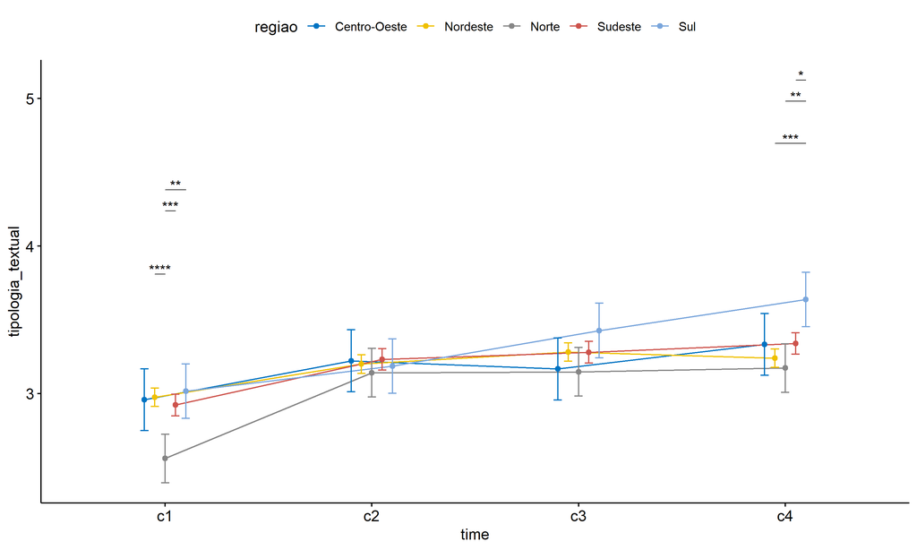

```r
pwc <- add_xy_position(pwc, x = "time", fun = "mean_se", dodge = 0.25)
pd <- position_dodge(width = 0.25)
ggline(emms, x = "time", y = "emmean", color = "regiao",
       palette = c("#0073C2FF","#EFC000FF","#868686FF","#CD534CFF","#7AA6DCFF"),
       position = pd, ylab = "tipologia_textual") +
  geom_errorbar(aes(ymin = conf.low, ymax = conf.high, color = regiao),
                position = pd, width = 0.2) +
  stat_pvalue_manual(pwc, hide.ns = T, tip.length = F, linetype = 1)
```

```r
(pwc <- ldat %>% group_by(regiao) %>%
    emmeans_test(tipologia_textual ~ time, detailed = T, p.adjust.method = "bonferroni"))
```

```
## # A tibble: 30 × 15
##    regiao    term  .y.   group1 group2 null.value estimate     se    df conf.low
##  * <fct>     <chr> <chr> <chr>  <chr>       <dbl>    <dbl>  <dbl> <dbl>    <dbl>
##  1 Centro-O… time  tipo… c1     c2              0  -0.264  0.151   4484   -0.561
##  2 Centro-O… time  tipo… c1     c3              0  -0.208  0.151   4484   -0.505
##  3 Centro-O… time  tipo… c1     c4              0  -0.375  0.151   4484   -0.672
##  4 Centro-O… time  tipo… c2     c3              0   0.0556 0.151   4484   -0.241
##  5 Centro-O… time  tipo… c2     c4              0  -0.111  0.151   4484   -0.408
##  6 Centro-O… time  tipo… c3     c4              0  -0.167  0.151   4484   -0.463
##  7 Nordeste  time  tipo… c1     c2              0  -0.225  0.0449  4484   -0.313
##  8 Nordeste  time  tipo… c1     c3              0  -0.307  0.0449  4484   -0.395
##  9 Nordeste  time  tipo… c1     c4              0  -0.266  0.0449  4484   -0.354
## 10 Nordeste  time  tipo… c2     c3              0  -0.0820 0.0449  4484   -0.170
## # ℹ 20 more rows
## # ℹ 5 more variables: conf.high <dbl>, statistic <dbl>, p <dbl>, p.adj <dbl>,
## #   p.adj.signif <chr>
```

| regiao | term | .y. | group1 | group2 | null.value | estimate | se | df | conf.low | conf.high | statistic | p | p.adj | p.adj.signif |
| --- | --- | --- | --- | --- | --- | --- | --- | --- | --- | --- | --- | --- | --- | --- |
| Centro-Oeste | time | tipologia_textual | c1 | c2 | 0 | -0.264 | 0.151 | 4484 | -0.561 | 0.033 | -1.743 | 0.081 | 0.488 | ns |
| Centro-Oeste | time | tipologia_textual | c1 | c3 | 0 | -0.208 | 0.151 | 4484 | -0.505 | 0.088 | -1.376 | 0.169 | 1.000 | ns |
| Centro-Oeste | time | tipologia_textual | c1 | c4 | 0 | -0.375 | 0.151 | 4484 | -0.672 | -0.078 | -2.477 | 0.013 | 0.080 | ns |
| Centro-Oeste | time | tipologia_textual | c2 | c3 | 0 | 0.056 | 0.151 | 4484 | -0.241 | 0.352 | 0.367 | 0.714 | 1.000 | ns |
| Centro-Oeste | time | tipologia_textual | c2 | c4 | 0 | -0.111 | 0.151 | 4484 | -0.408 | 0.186 | -0.734 | 0.463 | 1.000 | ns |
| Centro-Oeste | time | tipologia_textual | c3 | c4 | 0 | -0.167 | 0.151 | 4484 | -0.463 | 0.130 | -1.101 | 0.271 | 1.000 | ns |
| Nordeste | time | tipologia_textual | c1 | c2 | 0 | -0.225 | 0.045 | 4484 | -0.313 | -0.137 | -5.017 | 0.000 | 0.000 | **** |
| Nordeste | time | tipologia_textual | c1 | c3 | 0 | -0.307 | 0.045 | 4484 | -0.395 | -0.219 | -6.842 | 0.000 | 0.000 | **** |
| Nordeste | time | tipologia_textual | c1 | c4 | 0 | -0.266 | 0.045 | 4484 | -0.354 | -0.178 | -5.923 | 0.000 | 0.000 | **** |
| Nordeste | time | tipologia_textual | c2 | c3 | 0 | -0.082 | 0.045 | 4484 | -0.170 | 0.006 | -1.824 | 0.068 | 0.409 | ns |
| Nordeste | time | tipologia_textual | c2 | c4 | 0 | -0.041 | 0.045 | 4484 | -0.129 | 0.047 | -0.905 | 0.365 | 1.000 | ns |
| Nordeste | time | tipologia_textual | c3 | c4 | 0 | 0.041 | 0.045 | 4484 | -0.047 | 0.129 | 0.919 | 0.358 | 1.000 | ns |
| Norte | time | tipologia_textual | c1 | c2 | 0 | -0.581 | 0.119 | 4484 | -0.814 | -0.348 | -4.895 | 0.000 | 0.000 | **** |
| Norte | time | tipologia_textual | c1 | c3 | 0 | -0.588 | 0.119 | 4484 | -0.820 | -0.355 | -4.949 | 0.000 | 0.000 | **** |
| Norte | time | tipologia_textual | c1 | c4 | 0 | -0.613 | 0.119 | 4484 | -0.846 | -0.380 | -5.165 | 0.000 | 0.000 | **** |
| Norte | time | tipologia_textual | c2 | c3 | 0 | -0.006 | 0.119 | 4484 | -0.239 | 0.226 | -0.054 | 0.957 | 1.000 | ns |
| Norte | time | tipologia_textual | c2 | c4 | 0 | -0.032 | 0.119 | 4484 | -0.265 | 0.201 | -0.270 | 0.787 | 1.000 | ns |
| Norte | time | tipologia_textual | c3 | c4 | 0 | -0.026 | 0.119 | 4484 | -0.258 | 0.207 | -0.216 | 0.829 | 1.000 | ns |
| Sudeste | time | tipologia_textual | c1 | c2 | 0 | -0.309 | 0.053 | 4484 | -0.413 | -0.206 | -5.848 | 0.000 | 0.000 | **** |
| Sudeste | time | tipologia_textual | c1 | c3 | 0 | -0.358 | 0.053 | 4484 | -0.461 | -0.254 | -6.758 | 0.000 | 0.000 | **** |
| Sudeste | time | tipologia_textual | c1 | c4 | 0 | -0.417 | 0.053 | 4484 | -0.521 | -0.314 | -7.889 | 0.000 | 0.000 | **** |
| Sudeste | time | tipologia_textual | c2 | c3 | 0 | -0.048 | 0.053 | 4484 | -0.152 | 0.056 | -0.910 | 0.363 | 1.000 | ns |
| Sudeste | time | tipologia_textual | c2 | c4 | 0 | -0.108 | 0.053 | 4484 | -0.212 | -0.004 | -2.040 | 0.041 | 0.248 | ns |
| Sudeste | time | tipologia_textual | c3 | c4 | 0 | -0.060 | 0.053 | 4484 | -0.164 | 0.044 | -1.130 | 0.258 | 1.000 | ns |
| Sul | time | tipologia_textual | c1 | c2 | 0 | -0.171 | 0.133 | 4484 | -0.432 | 0.090 | -1.282 | 0.200 | 1.000 | ns |
| Sul | time | tipologia_textual | c1 | c3 | 0 | -0.411 | 0.133 | 4484 | -0.672 | -0.150 | -3.088 | 0.002 | 0.012 | * |
| Sul | time | tipologia_textual | c1 | c4 | 0 | -0.621 | 0.133 | 4484 | -0.882 | -0.360 | -4.663 | 0.000 | 0.000 | **** |
| Sul | time | tipologia_textual | c2 | c3 | 0 | -0.241 | 0.133 | 4484 | -0.502 | 0.021 | -1.806 | 0.071 | 0.425 | ns |
| Sul | time | tipologia_textual | c2 | c4 | 0 | -0.450 | 0.133 | 4484 | -0.711 | -0.189 | -3.381 | 0.001 | 0.004 | ** |
| Sul | time | tipologia_textual | c3 | c4 | 0 | -0.210 | 0.133 | 4484 | -0.471 | 0.051 | -1.574 | 0.115 | 0.693 | ns |

```r
(emms <- get_emmeans(pwc))
```

```
## # A tibble: 20 × 8
##    regiao       time  emmean     se    df conf.low conf.high method
##    <fct>        <fct>  <dbl>  <dbl> <dbl>    <dbl>     <dbl> <chr>
##  1 Centro-Oeste c1      2.96 0.107   4484     2.75      3.17 Emmeans test
##  2 Centro-Oeste c2      3.22 0.107   4484     3.01      3.43 Emmeans test
##  3 Centro-Oeste c3      3.17 0.107   4484     2.96      3.38 Emmeans test
##  4 Centro-Oeste c4      3.33 0.107   4484     3.12      3.54 Emmeans test
##  5 Nordeste     c1      2.97 0.0318  4484     2.91      3.04 Emmeans test
##  6 Nordeste     c2      3.20 0.0318  4484     3.14      3.26 Emmeans test
##  7 Nordeste     c3      3.28 0.0318  4484     3.22      3.34 Emmeans test
##  8 Nordeste     c4      3.24 0.0318  4484     3.18      3.30 Emmeans test
##  9 Norte        c1      2.56 0.0840  4484     2.40      2.72 Emmeans test
## 10 Norte        c2      3.14 0.0840  4484     2.98      3.31 Emmeans test
## 11 Norte        c3      3.15 0.0840  4484     2.98      3.31 Emmeans test
## 12 Norte        c4      3.17 0.0840  4484     3.01      3.34 Emmeans test
## 13 Sudeste      c1      2.92 0.0374  4484     2.85      3.00 Emmeans test
## 14 Sudeste      c2      3.23 0.0374  4484     3.16      3.31 Emmeans test
## 15 Sudeste      c3      3.28 0.0374  4484     3.21      3.35 Emmeans test
## 16 Sudeste      c4      3.34 0.0374  4484     3.27      3.41 Emmeans test
## 17 Sul          c1      3.02 0.0942  4484     2.83      3.20 Emmeans test
## 18 Sul          c2      3.19 0.0942  4484     3.00      3.37 Emmeans test
## 19 Sul          c3      3.43 0.0942  4484     3.24      3.61 Emmeans test
## 20 Sul          c4      3.64 0.0942  4484     3.45      3.82 Emmeans test
```

| regiao | time | emmean | se | df | conf.low | conf.high | method |
| --- | --- | --- | --- | --- | --- | --- | --- |
| Centro-Oeste | c1 | 2.958 | 0.107 | 4484 | 2.749 | 3.168 | Emmeans test |
| Centro-Oeste | c2 | 3.222 | 0.107 | 4484 | 3.012 | 3.432 | Emmeans test |
| Centro-Oeste | c3 | 3.167 | 0.107 | 4484 | 2.957 | 3.376 | Emmeans test |
| Centro-Oeste | c4 | 3.333 | 0.107 | 4484 | 3.124 | 3.543 | Emmeans test |
| Nordeste | c1 | 2.974 | 0.032 | 4484 | 2.912 | 3.037 | Emmeans test |
| Nordeste | c2 | 3.200 | 0.032 | 4484 | 3.137 | 3.262 | Emmeans test |
| Nordeste | c3 | 3.282 | 0.032 | 4484 | 3.219 | 3.344 | Emmeans test |
| Nordeste | c4 | 3.240 | 0.032 | 4484 | 3.178 | 3.303 | Emmeans test |
| Norte | c1 | 2.560 | 0.084 | 4484 | 2.395 | 2.724 | Emmeans test |
| Norte | c2 | 3.141 | 0.084 | 4484 | 2.976 | 3.306 | Emmeans test |
| Norte | c3 | 3.147 | 0.084 | 4484 | 2.983 | 3.312 | Emmeans test |
| Norte | c4 | 3.173 | 0.084 | 4484 | 3.008 | 3.338 | Emmeans test |
| Sudeste | c1 | 2.922 | 0.037 | 4484 | 2.849 | 2.996 | Emmeans test |
| Sudeste | c2 | 3.232 | 0.037 | 4484 | 3.158 | 3.305 | Emmeans test |
| Sudeste | c3 | 3.280 | 0.037 | 4484 | 3.207 | 3.353 | Emmeans test |
| Sudeste | c4 | 3.340 | 0.037 | 4484 | 3.266 | 3.413 | Emmeans test |
| Sul | c1 | 3.016 | 0.094 | 4484 | 2.832 | 3.201 | Emmeans test |
| Sul | c2 | 3.187 | 0.094 | 4484 | 3.002 | 3.371 | Emmeans test |
| Sul | c3 | 3.427 | 0.094 | 4484 | 3.243 | 3.612 | Emmeans test |
| Sul | c4 | 3.637 | 0.094 | 4484 | 3.452 | 3.822 | Emmeans test |

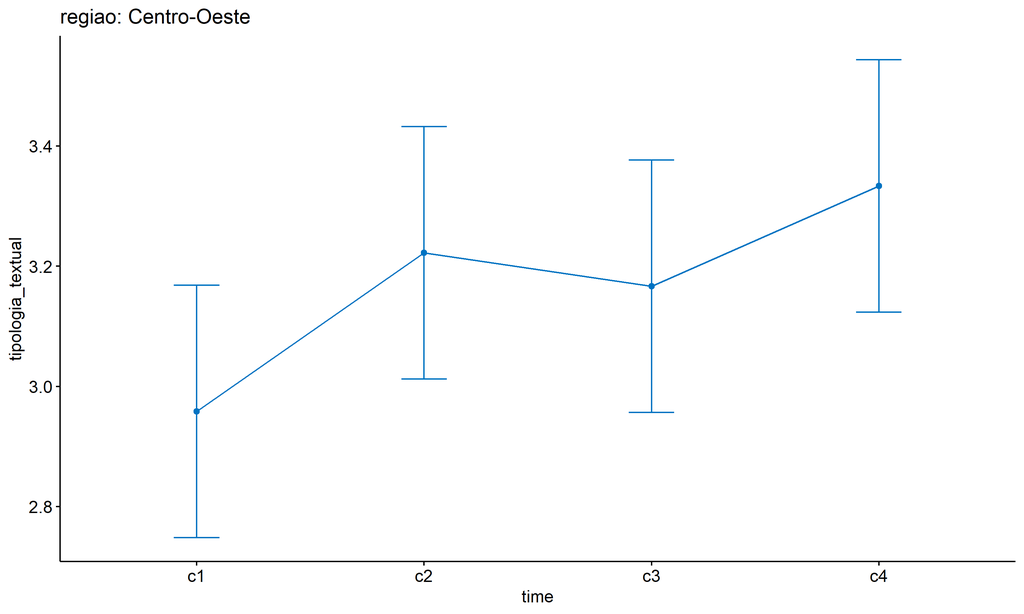

```r
emms.gg <- emms[which(emms$regiao == "Centro-Oeste"),]
if (nrow(emms.gg) > 0)
  ggline(emms.gg, x = "time", y = "emmean", color = "#0073C2FF", ylab = "tipologia_textual") +
    geom_errorbar(aes(ymin = conf.low, ymax = conf.high),
                  width = 0.2, color = "#0073C2FF") +
    stat_pvalue_manual(
      add_xy_position(pwc[which(pwc$regiao == "Centro-Oeste"),],
                      x = "time", fun = "mean_se"),
      hide.ns = T, color = "#0073C2FF", tip.length = F) +
    labs(title = "regiao: Centro-Oeste")+
    theme(legend.text = element_blank())
```

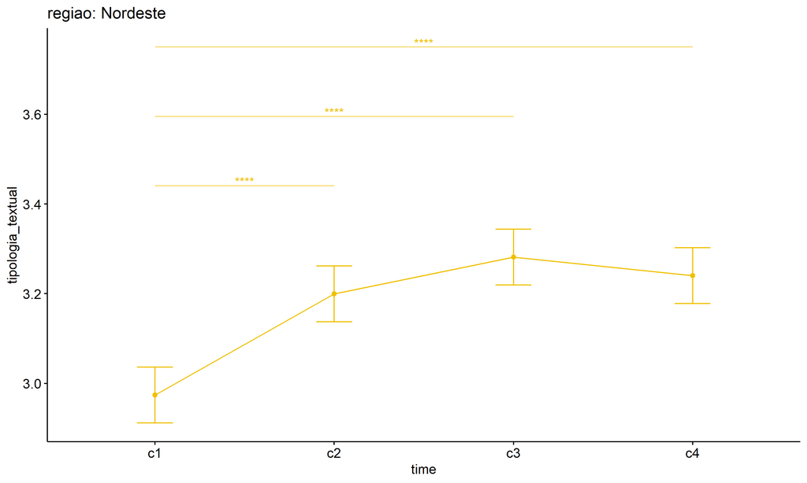

```r
emms.gg <- emms[which(emms$regiao == "Nordeste"),]
if (nrow(emms.gg) > 0)
  ggline(emms.gg, x = "time", y = "emmean", color = "#EFC000FF", ylab = "tipologia_textual") +
    geom_errorbar(aes(ymin = conf.low, ymax = conf.high),
                  width = 0.2, color = "#EFC000FF") +
    stat_pvalue_manual(
      add_xy_position(pwc[which(pwc$regiao == "Nordeste"),],
                      x = "time", fun = "mean_se"),
      hide.ns = T, color = "#EFC000FF", tip.length = F) +
    labs(title = "regiao: Nordeste")+
    theme(legend.text = element_blank())
```

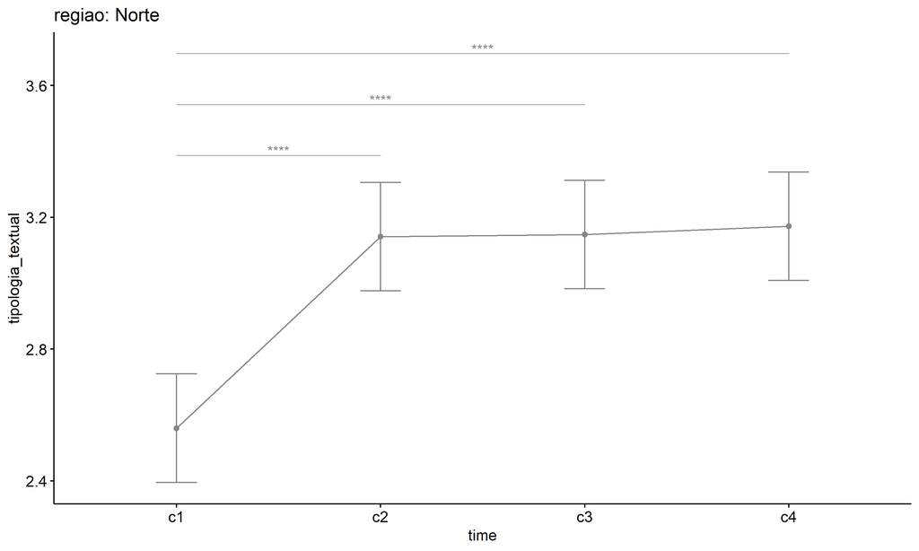

```r
emms.gg <- emms[which(emms$regiao == "Norte"),]
if (nrow(emms.gg) > 0)
  ggline(emms.gg, x = "time", y = "emmean", color = "#868686FF", ylab = "tipologia_textual") +
    geom_errorbar(aes(ymin = conf.low, ymax = conf.high),
                  width = 0.2, color = "#868686FF") +
    stat_pvalue_manual(
      add_xy_position(pwc[which(pwc$regiao == "Norte"),],
                      x = "time", fun = "mean_se"),
      hide.ns = T, color = "#868686FF", tip.length = F) +
    labs(title = "regiao: Norte")+
    theme(legend.text = element_blank())
```

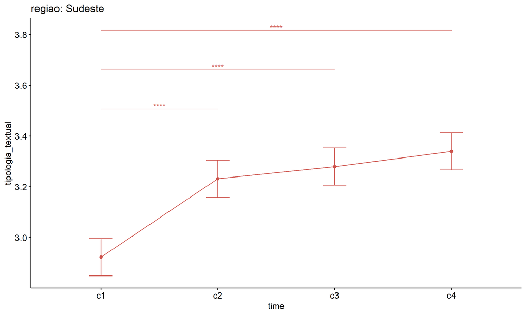

```r
emms.gg <- emms[which(emms$regiao == "Sudeste"),]
if (nrow(emms.gg) > 0)
  ggline(emms.gg, x = "time", y = "emmean", color = "#CD534CFF", ylab = "tipologia_textual") +
    geom_errorbar(aes(ymin = conf.low, ymax = conf.high),
                  width = 0.2, color = "#CD534CFF") +
    stat_pvalue_manual(
      add_xy_position(pwc[which(pwc$regiao == "Sudeste"),],
                      x = "time", fun = "mean_se"),
      hide.ns = T, color = "#CD534CFF", tip.length = F) +
    labs(title = "regiao: Sudeste")+
    theme(legend.text = element_blank())
```

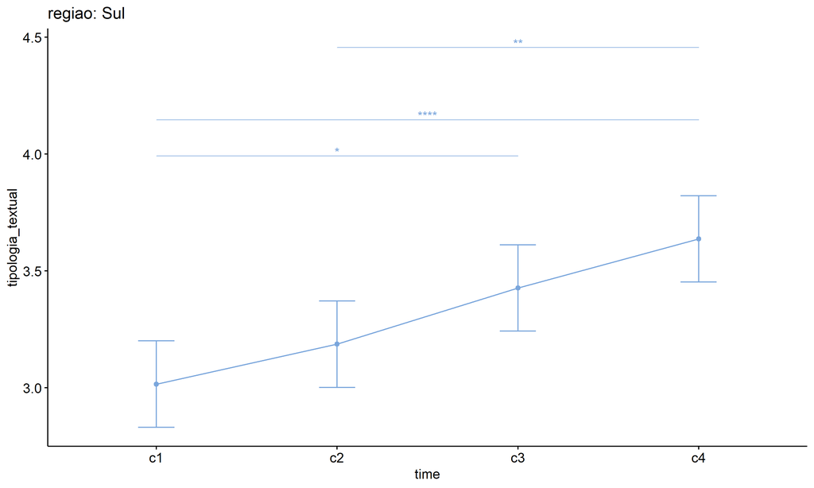

```r
emms.gg <- emms[which(emms$regiao == "Sul"),]
if (nrow(emms.gg) > 0)
  ggline(emms.gg, x = "time", y = "emmean", color = "#7AA6DCFF", ylab = "tipologia_textual") +
    geom_errorbar(aes(ymin = conf.low, ymax = conf.high),
                  width = 0.2, color = "#7AA6DCFF") +
    stat_pvalue_manual(
      add_xy_position(pwc[which(pwc$regiao == "Sul"),],
                      x = "time", fun = "mean_se"),
      hide.ns = T, color = "#7AA6DCFF", tip.length = F) +
    labs(title = "regiao: Sul")+
    theme(legend.text = element_blank())
```

# ANOVA: tipologia_textual ~ time*porte + Error(id/time)

## Data Preparation

```r
data <- edat[,c("aluno_id","porte","ciclo","tipologia_textual")]
data$ciclo <- factor(data$ciclo, c("Primeiro Ciclo","Segundo Ciclo",
                                   "Terceiro Ciclo","Quarto Ciclo"))

wdat <- spread(data, ciclo, tipologia_textual)
wdat <- wdat[complete.cases(wdat),]
colnames(wdat) <- c("id","porte","c1","c2","c3","c4")

ldat <- gather(wdat, key = time, value = tipologia_textual, c1, c2, c3, c4) %>%
  convert_as_factor(id, time)
ldat <- remove_group_data(ldat, "tipologia_textual", c("time", "porte"), n.limit = 30)
ldat$porte <- factor(ldat$porte, sort(unique(ldat$porte)))
```

### Check assumptions: Identifying Outliers

```r
outliers <- identify_outliers(group_by(ldat, time, porte), tipologia_textual)
(outliers <- outliers[outliers$is.extreme == T,])
```

```
## [1] porte             time              id                tipologia_textual
## [5] is.outlier        is.extreme
## <0 rows> (or 0-length row.names)
```

| porte | time | id | tipologia_textual | is.outlier | is.extreme |
| --- | --- | --- | --- | --- | --- |

### Check assumptions: Normality Test

```r
(normality.df <- normality.test.per.groups(ldat, "tipologia_textual", c("time", "porte")))
```

```
##                  var          variable time
## 1  tipologia_textual tipologia_textual   c1
## 2  tipologia_textual tipologia_textual   c1
## 3  tipologia_textual tipologia_textual   c1
## 4  tipologia_textual tipologia_textual   c1
## 5  tipologia_textual tipologia_textual   c2
## 6  tipologia_textual tipologia_textual   c2
## 7  tipologia_textual tipologia_textual   c2
## 8  tipologia_textual tipologia_textual   c2
## 9  tipologia_textual tipologia_textual   c3
## 10 tipologia_textual tipologia_textual   c3
## 11 tipologia_textual tipologia_textual   c3
## 12 tipologia_textual tipologia_textual   c3
## 13 tipologia_textual tipologia_textual   c4
## 14 tipologia_textual tipologia_textual   c4
```

[output cut: 36 more lines]

| var | variable | time | porte | n | skewness | kurtosis | symmetry | statistic | method | p | p.signif | normality |
| --- | --- | --- | --- | --- | --- | --- | --- | --- | --- | --- | --- | --- |
| tipologia_textual | tipologia_textual | c1 | Até 50 matrículas de escolarização | 33 | -0.246 | -1.451 | YES | 0.845 | Shapiro-Wilk | 0 | *** | NO |
| tipologia_textual | tipologia_textual | c1 | Entre 201 e 500 matrículas de escolarização | 675 | 0.096 | -1.311 | YES | 1331.804 | D’Agostino | 0 | **** | - |
| tipologia_textual | tipologia_textual | c1 | Entre 501 e 1000 matrículas de escolarização | 249 | 0.061 | -1.324 | YES | 272.586 | D’Agostino | 0 | **** | - |
| tipologia_textual | tipologia_textual | c1 | Entre 51 e 200 matrículas de escolarização | 162 | 0.226 | -1.486 | YES | 680.684 | D’Agostino | 0 | **** | QQ |
| tipologia_textual | tipologia_textual | c2 | Até 50 matrículas de escolarização | 33 | -0.278 | -1.172 | YES | 0.843 | Shapiro-Wilk | 0 | *** | NO |
| tipologia_textual | tipologia_textual | c2 | Entre 201 e 500 matrículas de escolarização | 675 | -0.437 | -1.079 | YES | 225.778 | D’Agostino | 0 | **** | - |
| tipologia_textual | tipologia_textual | c2 | Entre 501 e 1000 matrículas de escolarização | 249 | -0.359 | -1.298 | YES | 227.129 | D’Agostino | 0 | **** | - |
| tipologia_textual | tipologia_textual | c2 | Entre 51 e 200 matrículas de escolarização | 162 | -0.234 | -1.532 | YES | 5229.313 | D’Agostino | 0 | **** | QQ |
| tipologia_textual | tipologia_textual | c3 | Até 50 matrículas de escolarização | 33 | -0.406 | -1.064 | YES | 0.840 | Shapiro-Wilk | 0 | *** | NO |
| tipologia_textual | tipologia_textual | c3 | Entre 201 e 500 matrículas de escolarização | 675 | -0.490 | -0.971 | YES | 142.183 | D’Agostino | 0 | **** | - |
| tipologia_textual | tipologia_textual | c3 | Entre 501 e 1000 matrículas de escolarização | 249 | -0.634 | -0.949 | NO | 47.813 | D’Agostino | 0 | **** | - |
| tipologia_textual | tipologia_textual | c3 | Entre 51 e 200 matrículas de escolarização | 162 | -0.580 | -1.171 | NO | 61.132 | D’Agostino | 0 | **** | QQ |
| tipologia_textual | tipologia_textual | c4 | Até 50 matrículas de escolarização | 33 | -0.849 | -0.684 | NO | 0.749 | Shapiro-Wilk | 0 | **** | NO |
| tipologia_textual | tipologia_textual | c4 | Entre 201 e 500 matrículas de escolarização | 675 | -0.622 | -0.998 | NO | 171.979 | D’Agostino | 0 | **** | - |
| tipologia_textual | tipologia_textual | c4 | Entre 501 e 1000 matrículas de escolarização | 249 | -0.696 | -0.942 | NO | 49.459 | D’Agostino | 0 | **** | - |
| tipologia_textual | tipologia_textual | c4 | Entre 51 e 200 matrículas de escolarização | 162 | -0.167 | -1.445 | YES | 361.488 | D’Agostino | 0 | **** | QQ |

```r
(non.ids <- unique(do.call(
  c, lapply(which(normality.df$normality == 'NO'), FUN = function(i) {
  idx = which(ldat$time == normality.df$time[i] &
                ldat$porte == normality.df$porte[i])
  getNonNormal(ldat$"tipologia_textual"[idx], ldat$id[idx])
}))))
```

```
##  [1] "vgyELVyPKZx09yEhXnEW" "0bDRQAUpq62jJm9vcptp" "UgYoK4SY4Mtbi2xic7Rv"
##  [4] "ltYX0dLBB2brT2djXB5i" "ewKlsdM2p1FOYevFZJEB" "ADdqL4oAf1WRDDiOJwkj"
##  [7] "BFW9EcP6GxS4r3JYDkkn" "d7fkDImOtMuiednMD3E1" "8qKHWcxVACuKJJSMclyf"
## [10] "ygCWEOBsngyfEt5hGLmw" "7gsjMtGuUxQPUSVFnNcm" "0w3VhiMf67CbcpR6aZCL"
## [13] "Lbwu9s0newf9Wi294FdL" "BGXXXnQoaKaHn2dkhSeE" "z2bvFgOm1tRPAL3buvNQ"
## [16] "xAo0TzCEx1bIrmjqKgbj" "MdfO8FPiIZis82vN8Qvn" "xD1wHpF1gkJCyVbkGGdU"
## [19] "VNQYsv3kH0OTOqJH3yYT" "U2EyQT1K48KPitv2x16k" "hhm3dmBw9wzrZNM837xU"
## [22] "Rw0335zUaR2w467v8I7t" "8QJX5P6FygYXzjqA5njF" "w7548cNc0knlzDezHzBq"
## [25] "L0gX2yfP95da5eDy6w4E" "iutpBZMAtM92qcbyCDHB" "jljcKPNPjBo1MdiK1ffQ"
## [28] "hOmouhZRJ53dvfn3tBsJ" "1D0FkPiZPusHHIh6zphq" "KBTZEriJAFvcWw48Xxgc"
```

```r
if (length(non.ids) > 0)
  ldat2 <- ldat[!ldat$id %in% non.ids,]
```

### Summary Statistics

```r
(sdat <- ldat %>% group_by(time, porte) %>%
   get_summary_stats(tipologia_textual, type = "mean_sd"))
```

```
## # A tibble: 16 × 6
##    porte                                        time  variable     n  mean    sd
##    <fct>                                        <fct> <fct>    <dbl> <dbl> <dbl>
##  1 Até 50 matrículas de escolarização           c1    tipolog…    33  3.11 0.778
##  2 Entre 201 e 500 matrículas de escolarização  c1    tipolog…   675  2.93 0.744
##  3 Entre 501 e 1000 matrículas de escolarização c1    tipolog…   249  2.95 0.742
##  4 Entre 51 e 200 matrículas de escolarização   c1    tipolog…   162  2.86 0.796
##  5 Até 50 matrículas de escolarização           c2    tipolog…    33  3.23 0.697
##  6 Entre 201 e 500 matrículas de escolarização  c2    tipolog…   675  3.24 0.722
##  7 Entre 501 e 1000 matrículas de escolarização c2    tipolog…   249  3.18 0.77
##  8 Entre 51 e 200 matrículas de escolarização   c2    tipolog…   162  3.11 0.825
##  9 Até 50 matrículas de escolarização           c3    tipolog…    33  3.30 0.672
## 10 Entre 201 e 500 matrículas de escolarização  c3    tipolog…   675  3.26 0.71
## 11 Entre 501 e 1000 matrículas de escolarização c3    tipolog…   249  3.32 0.738
## 12 Entre 51 e 200 matrículas de escolarização   c3    tipolog…   162  3.31 0.766
## 13 Até 50 matrículas de escolarização           c4    tipolog…    33  3.44 0.715
## 14 Entre 201 e 500 matrículas de escolarização  c4    tipolog…   675  3.31 0.743
## 15 Entre 501 e 1000 matrículas de escolarização c4    tipolog…   249  3.36 0.735
## 16 Entre 51 e 200 matrículas de escolarização   c4    tipolog…   162  3.11 0.785
```

| porte | time | variable | n | mean | sd |
| --- | --- | --- | --- | --- | --- |
| Até 50 matrículas de escolarização | c1 | tipologia_textual | 33 | 3.106 | 0.778 |
| Entre 201 e 500 matrículas de escolarização | c1 | tipologia_textual | 675 | 2.932 | 0.744 |
| Entre 501 e 1000 matrículas de escolarização | c1 | tipologia_textual | 249 | 2.952 | 0.742 |
| Entre 51 e 200 matrículas de escolarização | c1 | tipologia_textual | 162 | 2.864 | 0.796 |
| Até 50 matrículas de escolarização | c2 | tipologia_textual | 33 | 3.227 | 0.697 |
| Entre 201 e 500 matrículas de escolarização | c2 | tipologia_textual | 675 | 3.240 | 0.722 |
| Entre 501 e 1000 matrículas de escolarização | c2 | tipologia_textual | 249 | 3.185 | 0.770 |
| Entre 51 e 200 matrículas de escolarização | c2 | tipologia_textual | 162 | 3.110 | 0.825 |
| Até 50 matrículas de escolarização | c3 | tipologia_textual | 33 | 3.303 | 0.672 |
| Entre 201 e 500 matrículas de escolarização | c3 | tipologia_textual | 675 | 3.259 | 0.710 |
| Entre 501 e 1000 matrículas de escolarização | c3 | tipologia_textual | 249 | 3.317 | 0.738 |
| Entre 51 e 200 matrículas de escolarização | c3 | tipologia_textual | 162 | 3.309 | 0.766 |
| Até 50 matrículas de escolarização | c4 | tipologia_textual | 33 | 3.439 | 0.715 |
| Entre 201 e 500 matrículas de escolarização | c4 | tipologia_textual | 675 | 3.310 | 0.743 |
| Entre 501 e 1000 matrículas de escolarização | c4 | tipologia_textual | 249 | 3.355 | 0.735 |
| Entre 51 e 200 matrículas de escolarização | c4 | tipologia_textual | 162 | 3.114 | 0.785 |

```r
if (length(non.ids) > 0)
  (sdat <- ldat2 %>% group_by(time, porte) %>%
      get_summary_stats(tipologia_textual, type = "mean_sd"))
```

```
## # A tibble: 16 × 6
##    porte                                        time  variable     n  mean    sd
##    <fct>                                        <fct> <fct>    <dbl> <dbl> <dbl>
##  1 Até 50 matrículas de escolarização           c1    tipolog…     3  3.33 1.16
##  2 Entre 201 e 500 matrículas de escolarização  c1    tipolog…   675  2.93 0.744
##  3 Entre 501 e 1000 matrículas de escolarização c1    tipolog…   249  2.95 0.742
##  4 Entre 51 e 200 matrículas de escolarização   c1    tipolog…   162  2.86 0.796
##  5 Até 50 matrículas de escolarização           c2    tipolog…     3  2.83 0.289
##  6 Entre 201 e 500 matrículas de escolarização  c2    tipolog…   675  3.24 0.722
##  7 Entre 501 e 1000 matrículas de escolarização c2    tipolog…   249  3.18 0.77
##  8 Entre 51 e 200 matrículas de escolarização   c2    tipolog…   162  3.11 0.825
##  9 Até 50 matrículas de escolarização           c3    tipolog…     3  3.17 0.764
## 10 Entre 201 e 500 matrículas de escolarização  c3    tipolog…   675  3.26 0.71
## 11 Entre 501 e 1000 matrículas de escolarização c3    tipolog…   249  3.32 0.738
## 12 Entre 51 e 200 matrículas de escolarização   c3    tipolog…   162  3.31 0.766
## 13 Até 50 matrículas de escolarização           c4    tipolog…     3  3.67 0.577
## 14 Entre 201 e 500 matrículas de escolarização  c4    tipolog…   675  3.31 0.743
## 15 Entre 501 e 1000 matrículas de escolarização c4    tipolog…   249  3.36 0.735
## 16 Entre 51 e 200 matrículas de escolarização   c4    tipolog…   162  3.11 0.785
```

| porte | time | variable | n | mean | sd |
| --- | --- | --- | --- | --- | --- |
| Até 50 matrículas de escolarização | c1 | tipologia_textual | 3 | 3.333 | 1.155 |
| Entre 201 e 500 matrículas de escolarização | c1 | tipologia_textual | 675 | 2.932 | 0.744 |
| Entre 501 e 1000 matrículas de escolarização | c1 | tipologia_textual | 249 | 2.952 | 0.742 |
| Entre 51 e 200 matrículas de escolarização | c1 | tipologia_textual | 162 | 2.864 | 0.796 |
| Até 50 matrículas de escolarização | c2 | tipologia_textual | 3 | 2.833 | 0.289 |
| Entre 201 e 500 matrículas de escolarização | c2 | tipologia_textual | 675 | 3.240 | 0.722 |
| Entre 501 e 1000 matrículas de escolarização | c2 | tipologia_textual | 249 | 3.185 | 0.770 |
| Entre 51 e 200 matrículas de escolarização | c2 | tipologia_textual | 162 | 3.110 | 0.825 |
| Até 50 matrículas de escolarização | c3 | tipologia_textual | 3 | 3.167 | 0.764 |
| Entre 201 e 500 matrículas de escolarização | c3 | tipologia_textual | 675 | 3.259 | 0.710 |
| Entre 501 e 1000 matrículas de escolarização | c3 | tipologia_textual | 249 | 3.317 | 0.738 |
| Entre 51 e 200 matrículas de escolarização | c3 | tipologia_textual | 162 | 3.309 | 0.766 |
| Até 50 matrículas de escolarização | c4 | tipologia_textual | 3 | 3.667 | 0.577 |
| Entre 201 e 500 matrículas de escolarização | c4 | tipologia_textual | 675 | 3.310 | 0.743 |
| Entre 501 e 1000 matrículas de escolarização | c4 | tipologia_textual | 249 | 3.355 | 0.735 |
| Entre 51 e 200 matrículas de escolarização | c4 | tipologia_textual | 162 | 3.114 | 0.785 |

## ANOVA Computation

```r
(res.aov <- anova_test(ldat, dv = tipologia_textual, wid = id, between = porte, within = time))
```

```
## ANOVA Table (type III tests)
##
## $ANOVA
##       Effect DFn  DFd      F        p p<.05   ges
## 1      porte   3 1115  2.377 6.80e-02       0.002
## 2       time   3 3345 20.836 2.26e-13     * 0.012
## 3 porte:time   9 3345  1.503 1.41e-01       0.003
##
## $`Mauchly's Test for Sphericity`
##       Effect     W        p p<.05
## 1       time 0.966 3.25e-07     *
## 2 porte:time 0.966 3.25e-07     *
##
## $`Sphericity Corrections`
##       Effect   GGe        DF[GG]    p[GG] p[GG]<.05  HFe        DF[HF]    p[HF]
## 1       time 0.977 2.93, 3267.44 4.07e-13         * 0.98 2.94, 3276.98 3.79e-13
## 2 porte:time 0.977 8.79, 3267.44 1.43e-01           0.98 8.82, 3276.98 1.43e-01
##   p[HF]<.05
## 1         *
## 2
```

| Effect | DFn | DFd | F | p | p<.05 | ges |
| --- | --- | --- | --- | --- | --- | --- |
| porte | 3 | 1115 | 2.377 | 0.068 |  | 0.002 |
| time | 3 | 3345 | 20.836 | 0.000 | * | 0.012 |
| porte:time | 9 | 3345 | 1.503 | 0.141 |  | 0.003 |

| Effect | W | p | p<.05 |
| --- | --- | --- | --- |
| time | 0.966 | 0 | * |
| porte:time | 0.966 | 0 | * |

| Effect | GGe | DF $$GG$$ | p $$GG$$ | p $$GG$$ <.05 | HFe | DF $$HF$$ | p $$HF$$ | p $$HF$$ <.05 |
| --- | --- | --- | --- | --- | --- | --- | --- | --- |
| time | 0.977 | 2.93, 3267.44 | 0.000 | * | 0.98 | 2.94, 3276.98 | 0.000 | * |
| porte:time | 0.977 | 8.79, 3267.44 | 0.143 |  | 0.98 | 8.82, 3276.98 | 0.143 |  |

## ANOVA Computation after removing non.normal data

```r
if (length(non.ids) > 0)
  (res.aov2 <- anova_test(ldat2, dv = tipologia_textual, wid = id, between = porte , within = time))
```

```
## ANOVA Table (type III tests)
##
## $ANOVA
##       Effect DFn  DFd     F     p p<.05   ges
## 1      porte   3 1085 1.951 0.120       0.002
## 2       time   3 3255 2.434 0.063       0.001
## 3 porte:time   9 3255 1.654 0.095       0.003
##
## $`Mauchly's Test for Sphericity`
##       Effect     W        p p<.05
## 1       time 0.962 7.44e-08     *
## 2 porte:time 0.962 7.44e-08     *
##
## $`Sphericity Corrections`
##       Effect   GGe        DF[GG] p[GG] p[GG]<.05   HFe        DF[HF] p[HF]
## 1       time 0.974 2.92, 3171.34 0.065           0.977 2.93, 3180.83 0.064
## 2 porte:time 0.974 8.77, 3171.34 0.097           0.977 8.79, 3180.83 0.097
##   p[HF]<.05
## 1
## 2
```

| Effect | DFn | DFd | F | p | p<.05 | ges |
| --- | --- | --- | --- | --- | --- | --- |
| porte | 3 | 1085 | 1.951 | 0.120 |  | 0.002 |
| time | 3 | 3255 | 2.434 | 0.063 |  | 0.001 |
| porte:time | 9 | 3255 | 1.654 | 0.095 |  | 0.003 |

| Effect | W | p | p<.05 |
| --- | --- | --- | --- |
| time | 0.962 | 0 | * |
| porte:time | 0.962 | 0 | * |

| Effect | GGe | DF $$GG$$ | p $$GG$$ | p $$GG$$ <.05 | HFe | DF $$HF$$ | p $$HF$$ | p $$HF$$ <.05 |
| --- | --- | --- | --- | --- | --- | --- | --- | --- |
| time | 0.974 | 2.92, 3171.34 | 0.065 |  | 0.977 | 2.93, 3180.83 | 0.064 |  |
| porte:time | 0.974 | 8.77, 3171.34 | 0.097 |  | 0.977 | 8.79, 3180.83 | 0.097 |  |

## PairWise Computation

```r
(pwc <- ldat %>% group_by(time) %>%
   emmeans_test(tipologia_textual ~ porte, detailed = T, p.adjust.method = "bonferroni"))
```

```
## # A tibble: 24 × 15
##    time  term  .y.       group1 group2 null.value estimate     se    df conf.low
##  * <fct> <chr> <chr>     <chr>  <chr>       <dbl>    <dbl>  <dbl> <dbl>    <dbl>
##  1 c1    porte tipologi… Até 5… Entre…          0   0.174  0.132   4460  -0.0854
##  2 c1    porte tipologi… Até 5… Entre…          0   0.154  0.138   4460  -0.116
##  3 c1    porte tipologi… Até 5… Entre…          0   0.242  0.142   4460  -0.0362
##  4 c1    porte tipologi… Entre… Entre…          0  -0.0206 0.0551  4460  -0.129
##  5 c1    porte tipologi… Entre… Entre…          0   0.0677 0.0650  4460  -0.0597
##  6 c1    porte tipologi… Entre… Entre…          0   0.0883 0.0750  4460  -0.0587
##  7 c2    porte tipologi… Até 5… Entre…          0  -0.0126 0.132   4460  -0.272
##  8 c2    porte tipologi… Até 5… Entre…          0   0.0425 0.138   4460  -0.227
##  9 c2    porte tipologi… Até 5… Entre…          0   0.118  0.142   4460  -0.160
## 10 c2    porte tipologi… Entre… Entre…          0   0.0551 0.0551  4460  -0.0528
## # ℹ 14 more rows
## # ℹ 5 more variables: conf.high <dbl>, statistic <dbl>, p <dbl>, p.adj <dbl>,
## #   p.adj.signif <chr>
```

| time | term | .y. | group1 | group2 | null.value | estimate | se | df | conf.low | conf.high | statistic | p | p.adj | p.adj.signif |
| --- | --- | --- | --- | --- | --- | --- | --- | --- | --- | --- | --- | --- | --- | --- |
| c1 | porte | tipologia_textual | Até 50 matrículas de escolarização | Entre 201 e 500 matrículas de escolarização | 0 | 0.174 | 0.132 | 4460 | -0.085 | 0.434 | 1.316 | 0.188 | 1.000 | ns |
| c1 | porte | tipologia_textual | Até 50 matrículas de escolarização | Entre 501 e 1000 matrículas de escolarização | 0 | 0.154 | 0.138 | 4460 | -0.116 | 0.423 | 1.116 | 0.264 | 1.000 | ns |
| c1 | porte | tipologia_textual | Até 50 matrículas de escolarização | Entre 51 e 200 matrículas de escolarização | 0 | 0.242 | 0.142 | 4460 | -0.036 | 0.520 | 1.705 | 0.088 | 0.529 | ns |
| c1 | porte | tipologia_textual | Entre 201 e 500 matrículas de escolarização | Entre 501 e 1000 matrículas de escolarização | 0 | -0.021 | 0.055 | 4460 | -0.129 | 0.087 | -0.375 | 0.708 | 1.000 | ns |
| c1 | porte | tipologia_textual | Entre 201 e 500 matrículas de escolarização | Entre 51 e 200 matrículas de escolarização | 0 | 0.068 | 0.065 | 4460 | -0.060 | 0.195 | 1.041 | 0.298 | 1.000 | ns |
| c1 | porte | tipologia_textual | Entre 501 e 1000 matrículas de escolarização | Entre 51 e 200 matrículas de escolarização | 0 | 0.088 | 0.075 | 4460 | -0.059 | 0.235 | 1.178 | 0.239 | 1.000 | ns |
| c2 | porte | tipologia_textual | Até 50 matrículas de escolarização | Entre 201 e 500 matrículas de escolarização | 0 | -0.013 | 0.132 | 4460 | -0.272 | 0.247 | -0.095 | 0.924 | 1.000 | ns |
| c2 | porte | tipologia_textual | Até 50 matrículas de escolarização | Entre 501 e 1000 matrículas de escolarização | 0 | 0.043 | 0.138 | 4460 | -0.227 | 0.312 | 0.309 | 0.757 | 1.000 | ns |
| c2 | porte | tipologia_textual | Até 50 matrículas de escolarização | Entre 51 e 200 matrículas de escolarização | 0 | 0.118 | 0.142 | 4460 | -0.160 | 0.396 | 0.830 | 0.407 | 1.000 | ns |
| c2 | porte | tipologia_textual | Entre 201 e 500 matrículas de escolarização | Entre 501 e 1000 matrículas de escolarização | 0 | 0.055 | 0.055 | 4460 | -0.053 | 0.163 | 1.001 | 0.317 | 1.000 | ns |
| c2 | porte | tipologia_textual | Entre 201 e 500 matrículas de escolarização | Entre 51 e 200 matrículas de escolarização | 0 | 0.130 | 0.065 | 4460 | 0.003 | 0.258 | 2.006 | 0.045 | 0.270 | ns |
| c2 | porte | tipologia_textual | Entre 501 e 1000 matrículas de escolarização | Entre 51 e 200 matrículas de escolarização | 0 | 0.075 | 0.075 | 4460 | -0.072 | 0.222 | 1.003 | 0.316 | 1.000 | ns |
| c3 | porte | tipologia_textual | Até 50 matrículas de escolarização | Entre 201 e 500 matrículas de escolarização | 0 | 0.045 | 0.132 | 4460 | -0.215 | 0.304 | 0.336 | 0.737 | 1.000 | ns |
| c3 | porte | tipologia_textual | Até 50 matrículas de escolarização | Entre 501 e 1000 matrículas de escolarização | 0 | -0.014 | 0.138 | 4460 | -0.284 | 0.255 | -0.103 | 0.918 | 1.000 | ns |
| c3 | porte | tipologia_textual | Até 50 matrículas de escolarização | Entre 51 e 200 matrículas de escolarização | 0 | -0.006 | 0.142 | 4460 | -0.284 | 0.272 | -0.040 | 0.968 | 1.000 | ns |
| c3 | porte | tipologia_textual | Entre 201 e 500 matrículas de escolarização | Entre 501 e 1000 matrículas de escolarização | 0 | -0.059 | 0.055 | 4460 | -0.167 | 0.049 | -1.067 | 0.286 | 1.000 | ns |
| c3 | porte | tipologia_textual | Entre 201 e 500 matrículas de escolarização | Entre 51 e 200 matrículas de escolarização | 0 | -0.050 | 0.065 | 4460 | -0.178 | 0.077 | -0.771 | 0.440 | 1.000 | ns |
| c3 | porte | tipologia_textual | Entre 501 e 1000 matrículas de escolarização | Entre 51 e 200 matrículas de escolarização | 0 | 0.009 | 0.075 | 4460 | -0.138 | 0.156 | 0.115 | 0.908 | 1.000 | ns |
| c4 | porte | tipologia_textual | Até 50 matrículas de escolarização | Entre 201 e 500 matrículas de escolarização | 0 | 0.130 | 0.132 | 4460 | -0.130 | 0.389 | 0.980 | 0.327 | 1.000 | ns |
| c4 | porte | tipologia_textual | Até 50 matrículas de escolarização | Entre 501 e 1000 matrículas de escolarização | 0 | 0.084 | 0.138 | 4460 | -0.186 | 0.354 | 0.610 | 0.542 | 1.000 | ns |
| c4 | porte | tipologia_textual | Até 50 matrículas de escolarização | Entre 51 e 200 matrículas de escolarização | 0 | 0.325 | 0.142 | 4460 | 0.047 | 0.603 | 2.293 | 0.022 | 0.131 | ns |
| c4 | porte | tipologia_textual | Entre 201 e 500 matrículas de escolarização | Entre 501 e 1000 matrículas de escolarização | 0 | -0.046 | 0.055 | 4460 | -0.154 | 0.062 | -0.832 | 0.406 | 1.000 | ns |
| c4 | porte | tipologia_textual | Entre 201 e 500 matrículas de escolarização | Entre 51 e 200 matrículas de escolarização | 0 | 0.195 | 0.065 | 4460 | 0.068 | 0.323 | 3.008 | 0.003 | 0.016 | * |
| c4 | porte | tipologia_textual | Entre 501 e 1000 matrículas de escolarização | Entre 51 e 200 matrículas de escolarização | 0 | 0.241 | 0.075 | 4460 | 0.094 | 0.388 | 3.218 | 0.001 | 0.008 | ** |

```r
(emms <- get_emmeans(pwc))
```

```
## # A tibble: 16 × 8
##    time  porte                     emmean     se    df conf.low conf.high method
##    <fct> <fct>                      <dbl>  <dbl> <dbl>    <dbl>     <dbl> <chr>
##  1 c1    Até 50 matrículas de esc…   3.11 0.129   4460     2.85      3.36 Emmea…
##  2 c1    Entre 201 e 500 matrícul…   2.93 0.0286  4460     2.88      2.99 Emmea…
##  3 c1    Entre 501 e 1000 matrícu…   2.95 0.0471  4460     2.86      3.04 Emmea…
##  4 c1    Entre 51 e 200 matrícula…   2.86 0.0583  4460     2.75      2.98 Emmea…
##  5 c2    Até 50 matrículas de esc…   3.23 0.129   4460     2.97      3.48 Emmea…
##  6 c2    Entre 201 e 500 matrícul…   3.24 0.0286  4460     3.18      3.30 Emmea…
##  7 c2    Entre 501 e 1000 matrícu…   3.18 0.0471  4460     3.09      3.28 Emmea…
##  8 c2    Entre 51 e 200 matrícula…   3.11 0.0583  4460     3.00      3.22 Emmea…
##  9 c3    Até 50 matrículas de esc…   3.30 0.129   4460     3.05      3.56 Emmea…
## 10 c3    Entre 201 e 500 matrícul…   3.26 0.0286  4460     3.20      3.31 Emmea…
## 11 c3    Entre 501 e 1000 matrícu…   3.32 0.0471  4460     3.22      3.41 Emmea…
## 12 c3    Entre 51 e 200 matrícula…   3.31 0.0583  4460     3.19      3.42 Emmea…
## 13 c4    Até 50 matrículas de esc…   3.44 0.129   4460     3.19      3.69 Emmea…
## 14 c4    Entre 201 e 500 matrícul…   3.31 0.0286  4460     3.25      3.37 Emmea…
## 15 c4    Entre 501 e 1000 matrícu…   3.36 0.0471  4460     3.26      3.45 Emmea…
## 16 c4    Entre 51 e 200 matrícula…   3.11 0.0583  4460     3.00      3.23 Emmea…
```

| time | porte | emmean | se | df | conf.low | conf.high | method |
| --- | --- | --- | --- | --- | --- | --- | --- |
| c1 | Até 50 matrículas de escolarização | 3.106 | 0.129 | 4460 | 2.853 | 3.360 | Emmeans test |
| c1 | Entre 201 e 500 matrículas de escolarização | 2.932 | 0.029 | 4460 | 2.876 | 2.988 | Emmeans test |
| c1 | Entre 501 e 1000 matrículas de escolarização | 2.952 | 0.047 | 4460 | 2.860 | 3.045 | Emmeans test |
| c1 | Entre 51 e 200 matrículas de escolarização | 2.864 | 0.058 | 4460 | 2.750 | 2.979 | Emmeans test |
| c2 | Até 50 matrículas de escolarização | 3.227 | 0.129 | 4460 | 2.974 | 3.481 | Emmeans test |
| c2 | Entre 201 e 500 matrículas de escolarização | 3.240 | 0.029 | 4460 | 3.184 | 3.296 | Emmeans test |
| c2 | Entre 501 e 1000 matrículas de escolarização | 3.185 | 0.047 | 4460 | 3.092 | 3.277 | Emmeans test |
| c2 | Entre 51 e 200 matrículas de escolarização | 3.110 | 0.058 | 4460 | 2.995 | 3.224 | Emmeans test |
| c3 | Até 50 matrículas de escolarização | 3.303 | 0.129 | 4460 | 3.050 | 3.556 | Emmeans test |
| c3 | Entre 201 e 500 matrículas de escolarização | 3.259 | 0.029 | 4460 | 3.202 | 3.315 | Emmeans test |
| c3 | Entre 501 e 1000 matrículas de escolarização | 3.317 | 0.047 | 4460 | 3.225 | 3.410 | Emmeans test |
| c3 | Entre 51 e 200 matrículas de escolarização | 3.309 | 0.058 | 4460 | 3.194 | 3.423 | Emmeans test |
| c4 | Até 50 matrículas de escolarização | 3.439 | 0.129 | 4460 | 3.186 | 3.693 | Emmeans test |
| c4 | Entre 201 e 500 matrículas de escolarização | 3.310 | 0.029 | 4460 | 3.254 | 3.366 | Emmeans test |
| c4 | Entre 501 e 1000 matrículas de escolarização | 3.355 | 0.047 | 4460 | 3.263 | 3.448 | Emmeans test |
| c4 | Entre 51 e 200 matrículas de escolarização | 3.114 | 0.058 | 4460 | 3.000 | 3.229 | Emmeans test |

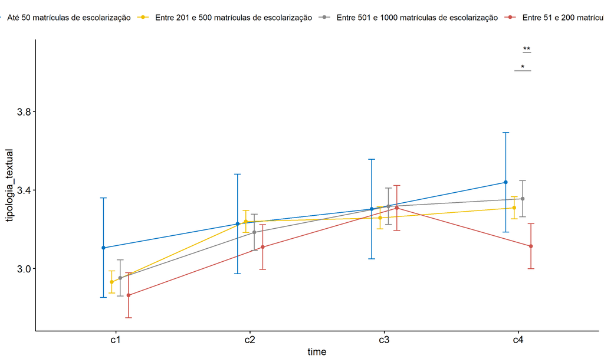

```r
pwc <- add_xy_position(pwc, x = "time", fun = "mean_se", dodge = 0.25)
pd <- position_dodge(width = 0.25)
ggline(emms, x = "time", y = "emmean", color = "porte",
       palette = c("#0073C2FF","#EFC000FF","#868686FF","#CD534CFF","#7AA6DCFF"),
       position = pd, ylab = "tipologia_textual") +
  geom_errorbar(aes(ymin = conf.low, ymax = conf.high, color = porte),
                position = pd, width = 0.2) +
  stat_pvalue_manual(pwc, hide.ns = T, tip.length = F, linetype = 1)
```

```r
(pwc <- ldat %>% group_by(porte) %>%
    emmeans_test(tipologia_textual ~ time, detailed = T, p.adjust.method = "bonferroni"))
```

```
## # A tibble: 24 × 15
##    porte     term  .y.   group1 group2 null.value estimate     se    df conf.low
##  * <fct>     <chr> <chr> <chr>  <chr>       <dbl>    <dbl>  <dbl> <dbl>    <dbl>
##  1 Até 50 m… time  tipo… c1     c2              0  -0.121  0.183   4460  -0.480
##  2 Até 50 m… time  tipo… c1     c3              0  -0.197  0.183   4460  -0.555
##  3 Até 50 m… time  tipo… c1     c4              0  -0.333  0.183   4460  -0.692
##  4 Até 50 m… time  tipo… c2     c3              0  -0.0758 0.183   4460  -0.434
##  5 Até 50 m… time  tipo… c2     c4              0  -0.212  0.183   4460  -0.571
##  6 Até 50 m… time  tipo… c3     c4              0  -0.136  0.183   4460  -0.495
##  7 Entre 20… time  tipo… c1     c2              0  -0.308  0.0404  4460  -0.387
##  8 Entre 20… time  tipo… c1     c3              0  -0.327  0.0404  4460  -0.406
##  9 Entre 20… time  tipo… c1     c4              0  -0.378  0.0404  4460  -0.457
## 10 Entre 20… time  tipo… c2     c3              0  -0.0186 0.0404  4460  -0.0979
## # ℹ 14 more rows
## # ℹ 5 more variables: conf.high <dbl>, statistic <dbl>, p <dbl>, p.adj <dbl>,
## #   p.adj.signif <chr>
```

| porte | term | .y. | group1 | group2 | null.value | estimate | se | df | conf.low | conf.high | statistic | p | p.adj | p.adj.signif |
| --- | --- | --- | --- | --- | --- | --- | --- | --- | --- | --- | --- | --- | --- | --- |
| Até 50 matrículas de escolarização | time | tipologia_textual | c1 | c2 | 0 | -0.121 | 0.183 | 4460 | -0.480 | 0.237 | -0.663 | 0.507 | 1.000 | ns |
| Até 50 matrículas de escolarização | time | tipologia_textual | c1 | c3 | 0 | -0.197 | 0.183 | 4460 | -0.555 | 0.161 | -1.077 | 0.281 | 1.000 | ns |
| Até 50 matrículas de escolarização | time | tipologia_textual | c1 | c4 | 0 | -0.333 | 0.183 | 4460 | -0.692 | 0.025 | -1.823 | 0.068 | 0.410 | ns |
| Até 50 matrículas de escolarização | time | tipologia_textual | c2 | c3 | 0 | -0.076 | 0.183 | 4460 | -0.434 | 0.283 | -0.414 | 0.679 | 1.000 | ns |
| Até 50 matrículas de escolarização | time | tipologia_textual | c2 | c4 | 0 | -0.212 | 0.183 | 4460 | -0.571 | 0.146 | -1.160 | 0.246 | 1.000 | ns |
| Até 50 matrículas de escolarização | time | tipologia_textual | c3 | c4 | 0 | -0.136 | 0.183 | 4460 | -0.495 | 0.222 | -0.746 | 0.456 | 1.000 | ns |
| Entre 201 e 500 matrículas de escolarização | time | tipologia_textual | c1 | c2 | 0 | -0.308 | 0.040 | 4460 | -0.387 | -0.229 | -7.620 | 0.000 | 0.000 | **** |
| Entre 201 e 500 matrículas de escolarização | time | tipologia_textual | c1 | c3 | 0 | -0.327 | 0.040 | 4460 | -0.406 | -0.247 | -8.081 | 0.000 | 0.000 | **** |
| Entre 201 e 500 matrículas de escolarização | time | tipologia_textual | c1 | c4 | 0 | -0.378 | 0.040 | 4460 | -0.457 | -0.299 | -9.345 | 0.000 | 0.000 | **** |
| Entre 201 e 500 matrículas de escolarização | time | tipologia_textual | c2 | c3 | 0 | -0.019 | 0.040 | 4460 | -0.098 | 0.061 | -0.461 | 0.645 | 1.000 | ns |
| Entre 201 e 500 matrículas de escolarização | time | tipologia_textual | c2 | c4 | 0 | -0.070 | 0.040 | 4460 | -0.149 | 0.010 | -1.725 | 0.085 | 0.507 | ns |
| Entre 201 e 500 matrículas de escolarização | time | tipologia_textual | c3 | c4 | 0 | -0.051 | 0.040 | 4460 | -0.130 | 0.028 | -1.264 | 0.206 | 1.000 | ns |
| Entre 501 e 1000 matrículas de escolarização | time | tipologia_textual | c1 | c2 | 0 | -0.232 | 0.067 | 4460 | -0.363 | -0.102 | -3.490 | 0.000 | 0.003 | ** |
| Entre 501 e 1000 matrículas de escolarização | time | tipologia_textual | c1 | c3 | 0 | -0.365 | 0.067 | 4460 | -0.495 | -0.234 | -5.481 | 0.000 | 0.000 | **** |
| Entre 501 e 1000 matrículas de escolarização | time | tipologia_textual | c1 | c4 | 0 | -0.403 | 0.067 | 4460 | -0.533 | -0.272 | -6.054 | 0.000 | 0.000 | **** |
| Entre 501 e 1000 matrículas de escolarização | time | tipologia_textual | c2 | c3 | 0 | -0.133 | 0.067 | 4460 | -0.263 | -0.002 | -1.991 | 0.047 | 0.279 | ns |
| Entre 501 e 1000 matrículas de escolarização | time | tipologia_textual | c2 | c4 | 0 | -0.171 | 0.067 | 4460 | -0.301 | -0.040 | -2.564 | 0.010 | 0.062 | ns |
| Entre 501 e 1000 matrículas de escolarização | time | tipologia_textual | c3 | c4 | 0 | -0.038 | 0.067 | 4460 | -0.169 | 0.092 | -0.573 | 0.567 | 1.000 | ns |
| Entre 51 e 200 matrículas de escolarização | time | tipologia_textual | c1 | c2 | 0 | -0.245 | 0.083 | 4460 | -0.407 | -0.084 | -2.974 | 0.003 | 0.018 | * |
| Entre 51 e 200 matrículas de escolarização | time | tipologia_textual | c1 | c3 | 0 | -0.444 | 0.083 | 4460 | -0.606 | -0.283 | -5.386 | 0.000 | 0.000 | **** |
| Entre 51 e 200 matrículas de escolarização | time | tipologia_textual | c1 | c4 | 0 | -0.250 | 0.083 | 4460 | -0.412 | -0.088 | -3.030 | 0.002 | 0.015 | * |
| Entre 51 e 200 matrículas de escolarização | time | tipologia_textual | c2 | c3 | 0 | -0.199 | 0.083 | 4460 | -0.361 | -0.037 | -2.412 | 0.016 | 0.095 | ns |
| Entre 51 e 200 matrículas de escolarização | time | tipologia_textual | c2 | c4 | 0 | -0.005 | 0.083 | 4460 | -0.166 | 0.157 | -0.056 | 0.955 | 1.000 | ns |
| Entre 51 e 200 matrículas de escolarização | time | tipologia_textual | c3 | c4 | 0 | 0.194 | 0.083 | 4460 | 0.033 | 0.356 | 2.356 | 0.018 | 0.111 | ns |

```r
(emms <- get_emmeans(pwc))
```

```
## # A tibble: 16 × 8
##    porte                     time  emmean     se    df conf.low conf.high method
##    <fct>                     <fct>  <dbl>  <dbl> <dbl>    <dbl>     <dbl> <chr>
##  1 Até 50 matrículas de esc… c1      3.11 0.129   4460     2.85      3.36 Emmea…
##  2 Até 50 matrículas de esc… c2      3.23 0.129   4460     2.97      3.48 Emmea…
##  3 Até 50 matrículas de esc… c3      3.30 0.129   4460     3.05      3.56 Emmea…
##  4 Até 50 matrículas de esc… c4      3.44 0.129   4460     3.19      3.69 Emmea…
##  5 Entre 201 e 500 matrícul… c1      2.93 0.0286  4460     2.88      2.99 Emmea…
##  6 Entre 201 e 500 matrícul… c2      3.24 0.0286  4460     3.18      3.30 Emmea…
##  7 Entre 201 e 500 matrícul… c3      3.26 0.0286  4460     3.20      3.31 Emmea…
##  8 Entre 201 e 500 matrícul… c4      3.31 0.0286  4460     3.25      3.37 Emmea…
##  9 Entre 501 e 1000 matrícu… c1      2.95 0.0471  4460     2.86      3.04 Emmea…
## 10 Entre 501 e 1000 matrícu… c2      3.18 0.0471  4460     3.09      3.28 Emmea…
## 11 Entre 501 e 1000 matrícu… c3      3.32 0.0471  4460     3.22      3.41 Emmea…
## 12 Entre 501 e 1000 matrícu… c4      3.36 0.0471  4460     3.26      3.45 Emmea…
## 13 Entre 51 e 200 matrícula… c1      2.86 0.0583  4460     2.75      2.98 Emmea…
## 14 Entre 51 e 200 matrícula… c2      3.11 0.0583  4460     3.00      3.22 Emmea…
## 15 Entre 51 e 200 matrícula… c3      3.31 0.0583  4460     3.19      3.42 Emmea…
## 16 Entre 51 e 200 matrícula… c4      3.11 0.0583  4460     3.00      3.23 Emmea…
```

| porte | time | emmean | se | df | conf.low | conf.high | method |
| --- | --- | --- | --- | --- | --- | --- | --- |
| Até 50 matrículas de escolarização | c1 | 3.106 | 0.129 | 4460 | 2.853 | 3.360 | Emmeans test |
| Até 50 matrículas de escolarização | c2 | 3.227 | 0.129 | 4460 | 2.974 | 3.481 | Emmeans test |
| Até 50 matrículas de escolarização | c3 | 3.303 | 0.129 | 4460 | 3.050 | 3.556 | Emmeans test |
| Até 50 matrículas de escolarização | c4 | 3.439 | 0.129 | 4460 | 3.186 | 3.693 | Emmeans test |
| Entre 201 e 500 matrículas de escolarização | c1 | 2.932 | 0.029 | 4460 | 2.876 | 2.988 | Emmeans test |
| Entre 201 e 500 matrículas de escolarização | c2 | 3.240 | 0.029 | 4460 | 3.184 | 3.296 | Emmeans test |
| Entre 201 e 500 matrículas de escolarização | c3 | 3.259 | 0.029 | 4460 | 3.202 | 3.315 | Emmeans test |
| Entre 201 e 500 matrículas de escolarização | c4 | 3.310 | 0.029 | 4460 | 3.254 | 3.366 | Emmeans test |
| Entre 501 e 1000 matrículas de escolarização | c1 | 2.952 | 0.047 | 4460 | 2.860 | 3.045 | Emmeans test |
| Entre 501 e 1000 matrículas de escolarização | c2 | 3.185 | 0.047 | 4460 | 3.092 | 3.277 | Emmeans test |
| Entre 501 e 1000 matrículas de escolarização | c3 | 3.317 | 0.047 | 4460 | 3.225 | 3.410 | Emmeans test |
| Entre 501 e 1000 matrículas de escolarização | c4 | 3.355 | 0.047 | 4460 | 3.263 | 3.448 | Emmeans test |
| Entre 51 e 200 matrículas de escolarização | c1 | 2.864 | 0.058 | 4460 | 2.750 | 2.979 | Emmeans test |
| Entre 51 e 200 matrículas de escolarização | c2 | 3.110 | 0.058 | 4460 | 2.995 | 3.224 | Emmeans test |
| Entre 51 e 200 matrículas de escolarização | c3 | 3.309 | 0.058 | 4460 | 3.194 | 3.423 | Emmeans test |
| Entre 51 e 200 matrículas de escolarização | c4 | 3.114 | 0.058 | 4460 | 3.000 | 3.229 | Emmeans test |

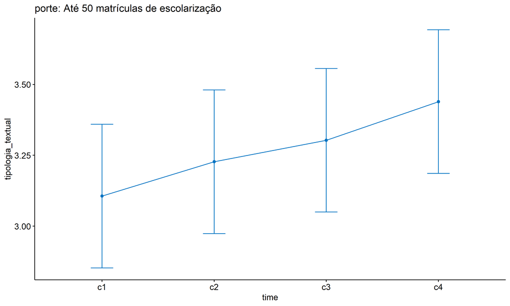

```r
emms.gg <- emms[which(emms$porte == "Até 50 matrículas de escolarização"),]
if (nrow(emms.gg) > 0)
  ggline(emms.gg, x = "time", y = "emmean", color = "#0073C2FF", ylab = "tipologia_textual") +
    geom_errorbar(aes(ymin = conf.low, ymax = conf.high),
                  width = 0.2, color = "#0073C2FF") +
    stat_pvalue_manual(
      add_xy_position(pwc[which(pwc$porte == "Até 50 matrículas de escolarização"),],
                      x = "time", fun = "mean_se"),
      hide.ns = T, color = "#0073C2FF", tip.length = F) +
    labs(title = "porte: Até 50 matrículas de escolarização")+
    theme(legend.text = element_blank())
```

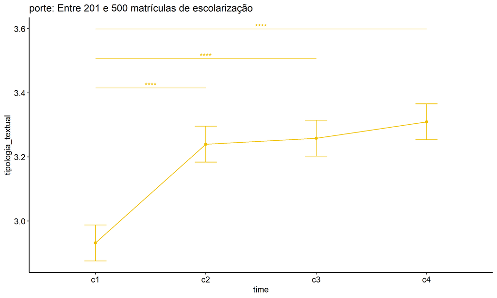

```r
emms.gg <- emms[which(emms$porte == "Entre 201 e 500 matrículas de escolarização"),]
if (nrow(emms.gg) > 0)
  ggline(emms.gg, x = "time", y = "emmean", color = "#EFC000FF", ylab = "tipologia_textual") +
    geom_errorbar(aes(ymin = conf.low, ymax = conf.high),
                  width = 0.2, color = "#EFC000FF") +
    stat_pvalue_manual(
      add_xy_position(pwc[which(pwc$porte == "Entre 201 e 500 matrículas de escolarização"),],
                      x = "time", fun = "mean_se"),
      hide.ns = T, color = "#EFC000FF", tip.length = F) +
    labs(title = "porte: Entre 201 e 500 matrículas de escolarização")+
    theme(legend.text = element_blank())
```

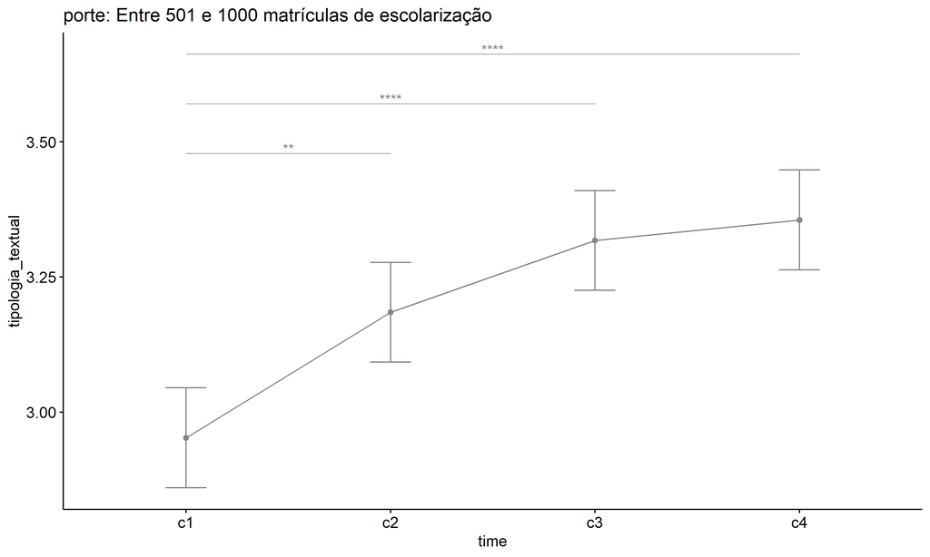

```r
emms.gg <- emms[which(emms$porte == "Entre 501 e 1000 matrículas de escolarização"),]
if (nrow(emms.gg) > 0)
  ggline(emms.gg, x = "time", y = "emmean", color = "#868686FF", ylab = "tipologia_textual") +
    geom_errorbar(aes(ymin = conf.low, ymax = conf.high),
                  width = 0.2, color = "#868686FF") +
    stat_pvalue_manual(
      add_xy_position(pwc[which(pwc$porte == "Entre 501 e 1000 matrículas de escolarização"),],
                      x = "time", fun = "mean_se"),
      hide.ns = T, color = "#868686FF", tip.length = F) +
    labs(title = "porte: Entre 501 e 1000 matrículas de escolarização")+
    theme(legend.text = element_blank())
```

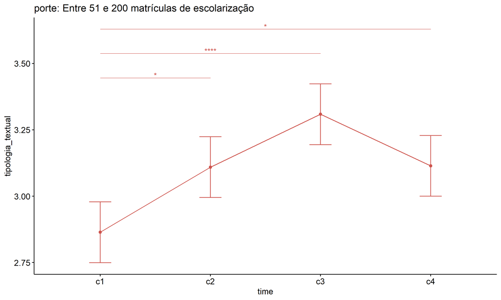

```r
emms.gg <- emms[which(emms$porte == "Entre 51 e 200 matrículas de escolarização"),]
if (nrow(emms.gg) > 0)
  ggline(emms.gg, x = "time", y = "emmean", color = "#CD534CFF", ylab = "tipologia_textual") +
    geom_errorbar(aes(ymin = conf.low, ymax = conf.high),
                  width = 0.2, color = "#CD534CFF") +
    stat_pvalue_manual(
      add_xy_position(pwc[which(pwc$porte == "Entre 51 e 200 matrículas de escolarização"),],
                      x = "time", fun = "mean_se"),
      hide.ns = T, color = "#CD534CFF", tip.length = F) +
    labs(title = "porte: Entre 51 e 200 matrículas de escolarização")+
    theme(legend.text = element_blank())
```

```r
emms.gg <- emms[which(emms$porte == "Mais de 1000 matrículas de escolarização"),]
if (nrow(emms.gg) > 0)
  ggline(emms.gg, x = "time", y = "emmean", color = "#7AA6DCFF", ylab = "tipologia_textual") +
    geom_errorbar(aes(ymin = conf.low, ymax = conf.high),
                  width = 0.2, color = "#7AA6DCFF") +
    stat_pvalue_manual(
      add_xy_position(pwc[which(pwc$porte == "Mais de 1000 matrículas de escolarização"),],
                      x = "time", fun = "mean_se"),
      hide.ns = T, color = "#7AA6DCFF", tip.length = F) +
    labs(title = "porte: Mais de 1000 matrículas de escolarização")+
    theme(legend.text = element_blank())
```

## PairWise Computation after removing non.normal data

```r
if (length(non.ids) > 0)
  (pwc2 <- ldat2 %>% group_by(time) %>%
     emmeans_test(tipologia_textual ~ porte, detailed = T, p.adjust.method = "bonferroni"))
```

```
## # A tibble: 24 × 15
##    time  term  .y.       group1 group2 null.value estimate     se    df conf.low
##  * <fct> <chr> <chr>     <chr>  <chr>       <dbl>    <dbl>  <dbl> <dbl>    <dbl>
##  1 c1    porte tipologi… Até 5… Entre…          0   0.401  0.430   4340  -0.442
##  2 c1    porte tipologi… Até 5… Entre…          0   0.381  0.432   4340  -0.466
##  3 c1    porte tipologi… Até 5… Entre…          0   0.469  0.433   4340  -0.380
##  4 c1    porte tipologi… Entre… Entre…          0  -0.0206 0.0551  4340  -0.129
##  5 c1    porte tipologi… Entre… Entre…          0   0.0677 0.0650  4340  -0.0599
##  6 c1    porte tipologi… Entre… Entre…          0   0.0883 0.0750  4340  -0.0588
##  7 c2    porte tipologi… Até 5… Entre…          0  -0.407  0.430   4340  -1.25
##  8 c2    porte tipologi… Até 5… Entre…          0  -0.351  0.432   4340  -1.20
##  9 c2    porte tipologi… Até 5… Entre…          0  -0.276  0.433   4340  -1.13
## 10 c2    porte tipologi… Entre… Entre…          0   0.0551 0.0551  4340  -0.0529
## # ℹ 14 more rows
## # ℹ 5 more variables: conf.high <dbl>, statistic <dbl>, p <dbl>, p.adj <dbl>,
## #   p.adj.signif <chr>
```

| time | term | .y. | group1 | group2 | null.value | estimate | se | df | conf.low | conf.high | statistic | p | p.adj | p.adj.signif |
| --- | --- | --- | --- | --- | --- | --- | --- | --- | --- | --- | --- | --- | --- | --- |
| c1 | porte | tipologia_textual | Até 50 matrículas de escolarização | Entre 201 e 500 matrículas de escolarização | 0 | 0.401 | 0.430 | 4340 | -0.442 | 1.245 | 0.933 | 0.351 | 1.000 | ns |
| c1 | porte | tipologia_textual | Até 50 matrículas de escolarização | Entre 501 e 1000 matrículas de escolarização | 0 | 0.381 | 0.432 | 4340 | -0.466 | 1.227 | 0.882 | 0.378 | 1.000 | ns |
| c1 | porte | tipologia_textual | Até 50 matrículas de escolarização | Entre 51 e 200 matrículas de escolarização | 0 | 0.469 | 0.433 | 4340 | -0.380 | 1.318 | 1.083 | 0.279 | 1.000 | ns |
| c1 | porte | tipologia_textual | Entre 201 e 500 matrículas de escolarização | Entre 501 e 1000 matrículas de escolarização | 0 | -0.021 | 0.055 | 4340 | -0.129 | 0.087 | -0.374 | 0.708 | 1.000 | ns |
| c1 | porte | tipologia_textual | Entre 201 e 500 matrículas de escolarização | Entre 51 e 200 matrículas de escolarização | 0 | 0.068 | 0.065 | 4340 | -0.060 | 0.195 | 1.040 | 0.298 | 1.000 | ns |
| c1 | porte | tipologia_textual | Entre 501 e 1000 matrículas de escolarização | Entre 51 e 200 matrículas de escolarização | 0 | 0.088 | 0.075 | 4340 | -0.059 | 0.235 | 1.176 | 0.240 | 1.000 | ns |
| c2 | porte | tipologia_textual | Até 50 matrículas de escolarização | Entre 201 e 500 matrículas de escolarização | 0 | -0.407 | 0.430 | 4340 | -1.250 | 0.437 | -0.945 | 0.345 | 1.000 | ns |
| c2 | porte | tipologia_textual | Até 50 matrículas de escolarização | Entre 501 e 1000 matrículas de escolarização | 0 | -0.351 | 0.432 | 4340 | -1.198 | 0.495 | -0.814 | 0.416 | 1.000 | ns |
| c2 | porte | tipologia_textual | Até 50 matrículas de escolarização | Entre 51 e 200 matrículas de escolarização | 0 | -0.276 | 0.433 | 4340 | -1.126 | 0.573 | -0.638 | 0.524 | 1.000 | ns |
| c2 | porte | tipologia_textual | Entre 201 e 500 matrículas de escolarização | Entre 501 e 1000 matrículas de escolarização | 0 | 0.055 | 0.055 | 4340 | -0.053 | 0.163 | 1.000 | 0.317 | 1.000 | ns |
| c2 | porte | tipologia_textual | Entre 201 e 500 matrículas de escolarização | Entre 51 e 200 matrículas de escolarização | 0 | 0.130 | 0.065 | 4340 | 0.003 | 0.258 | 2.003 | 0.045 | 0.271 | ns |
| c2 | porte | tipologia_textual | Entre 501 e 1000 matrículas de escolarização | Entre 51 e 200 matrículas de escolarização | 0 | 0.075 | 0.075 | 4340 | -0.072 | 0.222 | 1.002 | 0.317 | 1.000 | ns |
| c3 | porte | tipologia_textual | Até 50 matrículas de escolarização | Entre 201 e 500 matrículas de escolarização | 0 | -0.092 | 0.430 | 4340 | -0.935 | 0.752 | -0.214 | 0.831 | 1.000 | ns |
| c3 | porte | tipologia_textual | Até 50 matrículas de escolarização | Entre 501 e 1000 matrículas de escolarização | 0 | -0.151 | 0.432 | 4340 | -0.997 | 0.696 | -0.349 | 0.727 | 1.000 | ns |
| c3 | porte | tipologia_textual | Até 50 matrículas de escolarização | Entre 51 e 200 matrículas de escolarização | 0 | -0.142 | 0.433 | 4340 | -0.991 | 0.707 | -0.328 | 0.743 | 1.000 | ns |
| c3 | porte | tipologia_textual | Entre 201 e 500 matrículas de escolarização | Entre 501 e 1000 matrículas de escolarização | 0 | -0.059 | 0.055 | 4340 | -0.167 | 0.049 | -1.066 | 0.287 | 1.000 | ns |
| c3 | porte | tipologia_textual | Entre 201 e 500 matrículas de escolarização | Entre 51 e 200 matrículas de escolarização | 0 | -0.050 | 0.065 | 4340 | -0.178 | 0.077 | -0.771 | 0.441 | 1.000 | ns |
| c3 | porte | tipologia_textual | Entre 501 e 1000 matrículas de escolarização | Entre 51 e 200 matrículas de escolarização | 0 | 0.009 | 0.075 | 4340 | -0.138 | 0.156 | 0.115 | 0.908 | 1.000 | ns |
| c4 | porte | tipologia_textual | Até 50 matrículas de escolarização | Entre 201 e 500 matrículas de escolarização | 0 | 0.357 | 0.430 | 4340 | -0.486 | 1.200 | 0.830 | 0.407 | 1.000 | ns |
| c4 | porte | tipologia_textual | Até 50 matrículas de escolarização | Entre 501 e 1000 matrículas de escolarização | 0 | 0.311 | 0.432 | 4340 | -0.535 | 1.158 | 0.721 | 0.471 | 1.000 | ns |
| c4 | porte | tipologia_textual | Até 50 matrículas de escolarização | Entre 51 e 200 matrículas de escolarização | 0 | 0.552 | 0.433 | 4340 | -0.297 | 1.402 | 1.275 | 0.202 | 1.000 | ns |
| c4 | porte | tipologia_textual | Entre 201 e 500 matrículas de escolarização | Entre 501 e 1000 matrículas de escolarização | 0 | -0.046 | 0.055 | 4340 | -0.154 | 0.062 | -0.831 | 0.406 | 1.000 | ns |
| c4 | porte | tipologia_textual | Entre 201 e 500 matrículas de escolarização | Entre 51 e 200 matrículas de escolarização | 0 | 0.195 | 0.065 | 4340 | 0.068 | 0.323 | 3.005 | 0.003 | 0.016 | * |
| c4 | porte | tipologia_textual | Entre 501 e 1000 matrículas de escolarização | Entre 51 e 200 matrículas de escolarização | 0 | 0.241 | 0.075 | 4340 | 0.094 | 0.388 | 3.214 | 0.001 | 0.008 | ** |

```r
if (length(non.ids) > 0)
  (emms2 <- get_emmeans(pwc2))
```

```
## # A tibble: 16 × 8
##    time  porte                     emmean     se    df conf.low conf.high method
##    <fct> <fct>                      <dbl>  <dbl> <dbl>    <dbl>     <dbl> <chr>
##  1 c1    Até 50 matrículas de esc…   3.33 0.429   4340     2.49      4.17 Emmea…
##  2 c1    Entre 201 e 500 matrícul…   2.93 0.0286  4340     2.88      2.99 Emmea…
##  3 c1    Entre 501 e 1000 matrícu…   2.95 0.0471  4340     2.86      3.04 Emmea…
##  4 c1    Entre 51 e 200 matrícula…   2.86 0.0584  4340     2.75      2.98 Emmea…
##  5 c2    Até 50 matrículas de esc…   2.83 0.429   4340     1.99      3.67 Emmea…
##  6 c2    Entre 201 e 500 matrícul…   3.24 0.0286  4340     3.18      3.30 Emmea…
##  7 c2    Entre 501 e 1000 matrícu…   3.18 0.0471  4340     3.09      3.28 Emmea…
##  8 c2    Entre 51 e 200 matrícula…   3.11 0.0584  4340     3.00      3.22 Emmea…
##  9 c3    Até 50 matrículas de esc…   3.17 0.429   4340     2.33      4.01 Emmea…
## 10 c3    Entre 201 e 500 matrícul…   3.26 0.0286  4340     3.20      3.31 Emmea…
## 11 c3    Entre 501 e 1000 matrícu…   3.32 0.0471  4340     3.22      3.41 Emmea…
## 12 c3    Entre 51 e 200 matrícula…   3.31 0.0584  4340     3.19      3.42 Emmea…
## 13 c4    Até 50 matrículas de esc…   3.67 0.429   4340     2.83      4.51 Emmea…
## 14 c4    Entre 201 e 500 matrícul…   3.31 0.0286  4340     3.25      3.37 Emmea…
## 15 c4    Entre 501 e 1000 matrícu…   3.36 0.0471  4340     3.26      3.45 Emmea…
## 16 c4    Entre 51 e 200 matrícula…   3.11 0.0584  4340     3.00      3.23 Emmea…
```

| time | porte | emmean | se | df | conf.low | conf.high | method |
| --- | --- | --- | --- | --- | --- | --- | --- |
| c1 | Até 50 matrículas de escolarização | 3.333 | 0.429 | 4340 | 2.492 | 4.175 | Emmeans test |
| c1 | Entre 201 e 500 matrículas de escolarização | 2.932 | 0.029 | 4340 | 2.876 | 2.988 | Emmeans test |
| c1 | Entre 501 e 1000 matrículas de escolarização | 2.952 | 0.047 | 4340 | 2.860 | 3.045 | Emmeans test |
| c1 | Entre 51 e 200 matrículas de escolarização | 2.864 | 0.058 | 4340 | 2.750 | 2.979 | Emmeans test |
| c2 | Até 50 matrículas de escolarização | 2.833 | 0.429 | 4340 | 1.992 | 3.675 | Emmeans test |
| c2 | Entre 201 e 500 matrículas de escolarização | 3.240 | 0.029 | 4340 | 3.184 | 3.296 | Emmeans test |
| c2 | Entre 501 e 1000 matrículas de escolarização | 3.185 | 0.047 | 4340 | 3.092 | 3.277 | Emmeans test |
| c2 | Entre 51 e 200 matrículas de escolarização | 3.110 | 0.058 | 4340 | 2.995 | 3.224 | Emmeans test |
| c3 | Até 50 matrículas de escolarização | 3.167 | 0.429 | 4340 | 2.325 | 4.008 | Emmeans test |
| c3 | Entre 201 e 500 matrículas de escolarização | 3.259 | 0.029 | 4340 | 3.202 | 3.315 | Emmeans test |
| c3 | Entre 501 e 1000 matrículas de escolarização | 3.317 | 0.047 | 4340 | 3.225 | 3.410 | Emmeans test |
| c3 | Entre 51 e 200 matrículas de escolarização | 3.309 | 0.058 | 4340 | 3.194 | 3.423 | Emmeans test |
| c4 | Até 50 matrículas de escolarização | 3.667 | 0.429 | 4340 | 2.825 | 4.508 | Emmeans test |
| c4 | Entre 201 e 500 matrículas de escolarização | 3.310 | 0.029 | 4340 | 3.254 | 3.366 | Emmeans test |
| c4 | Entre 501 e 1000 matrículas de escolarização | 3.355 | 0.047 | 4340 | 3.263 | 3.448 | Emmeans test |
| c4 | Entre 51 e 200 matrículas de escolarização | 3.114 | 0.058 | 4340 | 3.000 | 3.229 | Emmeans test |

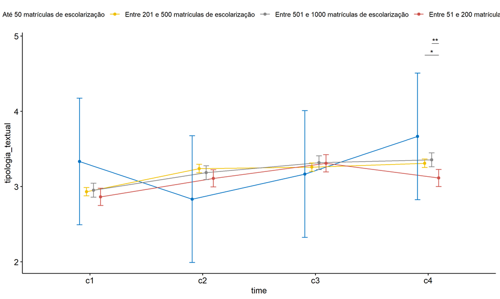

```r
if (length(non.ids) > 0) {
  pwc2 <- add_xy_position(pwc2, x = "time", fun = "mean_se", dodge = 0.25)
  pd2 <- position_dodge(width = 0.25)

  ggline(emms2, x = "time", y = "emmean", color = "porte",
         palette = c("#0073C2FF","#EFC000FF","#868686FF","#CD534CFF","#7AA6DCFF"),
         position = pd, ylab = "tipologia_textual") +
    geom_errorbar(aes(ymin = conf.low, ymax = conf.high, color = porte),
                position = pd, width = 0.2) +
    stat_pvalue_manual(pwc2, hide.ns = T, tip.length = F, linetype = 1)
}
```

```r
if (length(non.ids) > 0)
  (pwc2 <- ldat2 %>% group_by(porte) %>%
     emmeans_test(tipologia_textual ~ time, detailed = T, p.adjust.method = "bonferroni"))
```

```
## # A tibble: 24 × 15
##    porte     term  .y.   group1 group2 null.value estimate     se    df conf.low
##  * <fct>     <chr> <chr> <chr>  <chr>       <dbl>    <dbl>  <dbl> <dbl>    <dbl>
##  1 Até 50 m… time  tipo… c1     c2              0   0.500  0.607   4340  -0.690
##  2 Até 50 m… time  tipo… c1     c3              0   0.167  0.607   4340  -1.02
##  3 Até 50 m… time  tipo… c1     c4              0  -0.333  0.607   4340  -1.52
##  4 Até 50 m… time  tipo… c2     c3              0  -0.333  0.607   4340  -1.52
##  5 Até 50 m… time  tipo… c2     c4              0  -0.833  0.607   4340  -2.02
##  6 Até 50 m… time  tipo… c3     c4              0  -0.500  0.607   4340  -1.69
##  7 Entre 20… time  tipo… c1     c2              0  -0.308  0.0405  4340  -0.387
##  8 Entre 20… time  tipo… c1     c3              0  -0.327  0.0405  4340  -0.406
##  9 Entre 20… time  tipo… c1     c4              0  -0.378  0.0405  4340  -0.457
## 10 Entre 20… time  tipo… c2     c3              0  -0.0186 0.0405  4340  -0.0980
## # ℹ 14 more rows
## # ℹ 5 more variables: conf.high <dbl>, statistic <dbl>, p <dbl>, p.adj <dbl>,
## #   p.adj.signif <chr>
```

| porte | term | .y. | group1 | group2 | null.value | estimate | se | df | conf.low | conf.high | statistic | p | p.adj | p.adj.signif |
| --- | --- | --- | --- | --- | --- | --- | --- | --- | --- | --- | --- | --- | --- | --- |
| Até 50 matrículas de escolarização | time | tipologia_textual | c1 | c2 | 0 | 0.500 | 0.607 | 4340 | -0.690 | 1.690 | 0.824 | 0.410 | 1.000 | ns |
| Até 50 matrículas de escolarização | time | tipologia_textual | c1 | c3 | 0 | 0.167 | 0.607 | 4340 | -1.023 | 1.357 | 0.275 | 0.784 | 1.000 | ns |
| Até 50 matrículas de escolarização | time | tipologia_textual | c1 | c4 | 0 | -0.333 | 0.607 | 4340 | -1.523 | 0.857 | -0.549 | 0.583 | 1.000 | ns |
| Até 50 matrículas de escolarização | time | tipologia_textual | c2 | c3 | 0 | -0.333 | 0.607 | 4340 | -1.523 | 0.857 | -0.549 | 0.583 | 1.000 | ns |
| Até 50 matrículas de escolarização | time | tipologia_textual | c2 | c4 | 0 | -0.833 | 0.607 | 4340 | -2.023 | 0.357 | -1.373 | 0.170 | 1.000 | ns |
| Até 50 matrículas de escolarização | time | tipologia_textual | c3 | c4 | 0 | -0.500 | 0.607 | 4340 | -1.690 | 0.690 | -0.824 | 0.410 | 1.000 | ns |
| Entre 201 e 500 matrículas de escolarização | time | tipologia_textual | c1 | c2 | 0 | -0.308 | 0.040 | 4340 | -0.387 | -0.229 | -7.611 | 0.000 | 0.000 | **** |
| Entre 201 e 500 matrículas de escolarização | time | tipologia_textual | c1 | c3 | 0 | -0.327 | 0.040 | 4340 | -0.406 | -0.247 | -8.072 | 0.000 | 0.000 | **** |
| Entre 201 e 500 matrículas de escolarização | time | tipologia_textual | c1 | c4 | 0 | -0.378 | 0.040 | 4340 | -0.457 | -0.298 | -9.335 | 0.000 | 0.000 | **** |
| Entre 201 e 500 matrículas de escolarização | time | tipologia_textual | c2 | c3 | 0 | -0.019 | 0.040 | 4340 | -0.098 | 0.061 | -0.461 | 0.645 | 1.000 | ns |
| Entre 201 e 500 matrículas de escolarização | time | tipologia_textual | c2 | c4 | 0 | -0.070 | 0.040 | 4340 | -0.149 | 0.010 | -1.724 | 0.085 | 0.509 | ns |
| Entre 201 e 500 matrículas de escolarização | time | tipologia_textual | c3 | c4 | 0 | -0.051 | 0.040 | 4340 | -0.130 | 0.028 | -1.263 | 0.207 | 1.000 | ns |
| Entre 501 e 1000 matrículas de escolarização | time | tipologia_textual | c1 | c2 | 0 | -0.232 | 0.067 | 4340 | -0.363 | -0.102 | -3.486 | 0.000 | 0.003 | ** |
| Entre 501 e 1000 matrículas de escolarização | time | tipologia_textual | c1 | c3 | 0 | -0.365 | 0.067 | 4340 | -0.495 | -0.234 | -5.475 | 0.000 | 0.000 | **** |
| Entre 501 e 1000 matrículas de escolarização | time | tipologia_textual | c1 | c4 | 0 | -0.403 | 0.067 | 4340 | -0.534 | -0.272 | -6.047 | 0.000 | 0.000 | **** |
| Entre 501 e 1000 matrículas de escolarização | time | tipologia_textual | c2 | c3 | 0 | -0.133 | 0.067 | 4340 | -0.263 | -0.002 | -1.989 | 0.047 | 0.281 | ns |
| Entre 501 e 1000 matrículas de escolarização | time | tipologia_textual | c2 | c4 | 0 | -0.171 | 0.067 | 4340 | -0.301 | -0.040 | -2.562 | 0.010 | 0.063 | ns |
| Entre 501 e 1000 matrículas de escolarização | time | tipologia_textual | c3 | c4 | 0 | -0.038 | 0.067 | 4340 | -0.169 | 0.092 | -0.573 | 0.567 | 1.000 | ns |
| Entre 51 e 200 matrículas de escolarização | time | tipologia_textual | c1 | c2 | 0 | -0.245 | 0.083 | 4340 | -0.407 | -0.083 | -2.970 | 0.003 | 0.018 | * |
| Entre 51 e 200 matrículas de escolarização | time | tipologia_textual | c1 | c3 | 0 | -0.444 | 0.083 | 4340 | -0.606 | -0.282 | -5.380 | 0.000 | 0.000 | **** |
| Entre 51 e 200 matrículas de escolarização | time | tipologia_textual | c1 | c4 | 0 | -0.250 | 0.083 | 4340 | -0.412 | -0.088 | -3.026 | 0.002 | 0.015 | * |
| Entre 51 e 200 matrículas de escolarização | time | tipologia_textual | c2 | c3 | 0 | -0.199 | 0.083 | 4340 | -0.361 | -0.037 | -2.410 | 0.016 | 0.096 | ns |
| Entre 51 e 200 matrículas de escolarização | time | tipologia_textual | c2 | c4 | 0 | -0.005 | 0.083 | 4340 | -0.167 | 0.157 | -0.056 | 0.955 | 1.000 | ns |
| Entre 51 e 200 matrículas de escolarização | time | tipologia_textual | c3 | c4 | 0 | 0.194 | 0.083 | 4340 | 0.032 | 0.356 | 2.354 | 0.019 | 0.112 | ns |

```r
if (length(non.ids) > 0)
  (emms2 <- get_emmeans(pwc2))
```

```
## # A tibble: 16 × 8
##    porte                     time  emmean     se    df conf.low conf.high method
##    <fct>                     <fct>  <dbl>  <dbl> <dbl>    <dbl>     <dbl> <chr>
##  1 Até 50 matrículas de esc… c1      3.33 0.429   4340     2.49      4.17 Emmea…
##  2 Até 50 matrículas de esc… c2      2.83 0.429   4340     1.99      3.67 Emmea…
##  3 Até 50 matrículas de esc… c3      3.17 0.429   4340     2.33      4.01 Emmea…
##  4 Até 50 matrículas de esc… c4      3.67 0.429   4340     2.83      4.51 Emmea…
##  5 Entre 201 e 500 matrícul… c1      2.93 0.0286  4340     2.88      2.99 Emmea…
##  6 Entre 201 e 500 matrícul… c2      3.24 0.0286  4340     3.18      3.30 Emmea…
##  7 Entre 201 e 500 matrícul… c3      3.26 0.0286  4340     3.20      3.31 Emmea…
##  8 Entre 201 e 500 matrícul… c4      3.31 0.0286  4340     3.25      3.37 Emmea…
##  9 Entre 501 e 1000 matrícu… c1      2.95 0.0471  4340     2.86      3.04 Emmea…
## 10 Entre 501 e 1000 matrícu… c2      3.18 0.0471  4340     3.09      3.28 Emmea…
## 11 Entre 501 e 1000 matrícu… c3      3.32 0.0471  4340     3.22      3.41 Emmea…
## 12 Entre 501 e 1000 matrícu… c4      3.36 0.0471  4340     3.26      3.45 Emmea…
## 13 Entre 51 e 200 matrícula… c1      2.86 0.0584  4340     2.75      2.98 Emmea…
## 14 Entre 51 e 200 matrícula… c2      3.11 0.0584  4340     3.00      3.22 Emmea…
## 15 Entre 51 e 200 matrícula… c3      3.31 0.0584  4340     3.19      3.42 Emmea…
## 16 Entre 51 e 200 matrícula… c4      3.11 0.0584  4340     3.00      3.23 Emmea…
```

| porte | time | emmean | se | df | conf.low | conf.high | method |
| --- | --- | --- | --- | --- | --- | --- | --- |
| Até 50 matrículas de escolarização | c1 | 3.333 | 0.429 | 4340 | 2.492 | 4.175 | Emmeans test |
| Até 50 matrículas de escolarização | c2 | 2.833 | 0.429 | 4340 | 1.992 | 3.675 | Emmeans test |
| Até 50 matrículas de escolarização | c3 | 3.167 | 0.429 | 4340 | 2.325 | 4.008 | Emmeans test |
| Até 50 matrículas de escolarização | c4 | 3.667 | 0.429 | 4340 | 2.825 | 4.508 | Emmeans test |
| Entre 201 e 500 matrículas de escolarização | c1 | 2.932 | 0.029 | 4340 | 2.876 | 2.988 | Emmeans test |
| Entre 201 e 500 matrículas de escolarização | c2 | 3.240 | 0.029 | 4340 | 3.184 | 3.296 | Emmeans test |
| Entre 201 e 500 matrículas de escolarização | c3 | 3.259 | 0.029 | 4340 | 3.202 | 3.315 | Emmeans test |
| Entre 201 e 500 matrículas de escolarização | c4 | 3.310 | 0.029 | 4340 | 3.254 | 3.366 | Emmeans test |
| Entre 501 e 1000 matrículas de escolarização | c1 | 2.952 | 0.047 | 4340 | 2.860 | 3.045 | Emmeans test |
| Entre 501 e 1000 matrículas de escolarização | c2 | 3.185 | 0.047 | 4340 | 3.092 | 3.277 | Emmeans test |
| Entre 501 e 1000 matrículas de escolarização | c3 | 3.317 | 0.047 | 4340 | 3.225 | 3.410 | Emmeans test |
| Entre 501 e 1000 matrículas de escolarização | c4 | 3.355 | 0.047 | 4340 | 3.263 | 3.448 | Emmeans test |
| Entre 51 e 200 matrículas de escolarização | c1 | 2.864 | 0.058 | 4340 | 2.750 | 2.979 | Emmeans test |
| Entre 51 e 200 matrículas de escolarização | c2 | 3.110 | 0.058 | 4340 | 2.995 | 3.224 | Emmeans test |
| Entre 51 e 200 matrículas de escolarização | c3 | 3.309 | 0.058 | 4340 | 3.194 | 3.423 | Emmeans test |
| Entre 51 e 200 matrículas de escolarização | c4 | 3.114 | 0.058 | 4340 | 3.000 | 3.229 | Emmeans test |

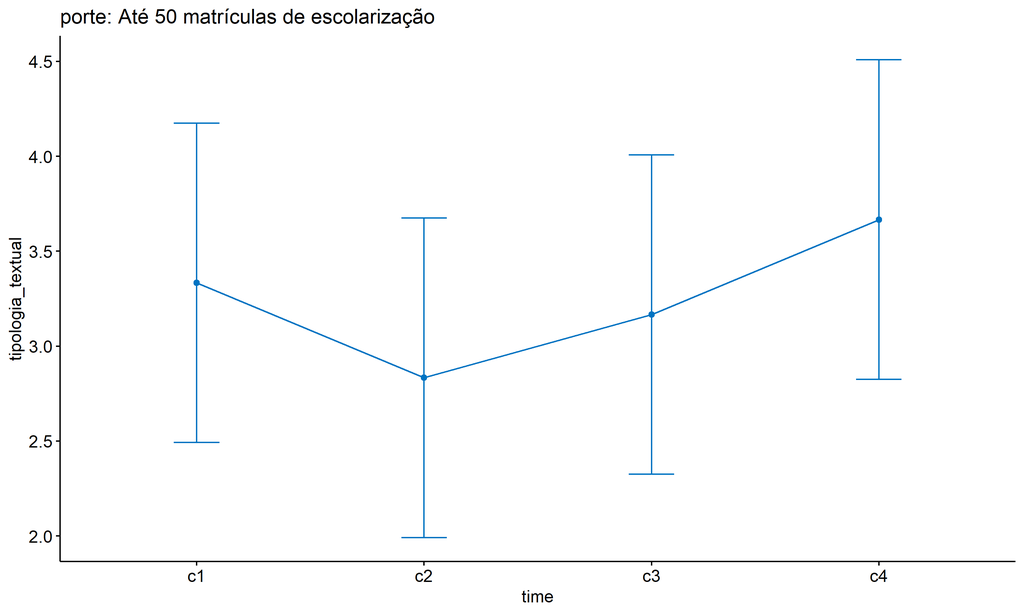

```r
if (length(non.ids) > 0) {
  emms.gg <- emms2[which(emms2$porte == "Até 50 matrículas de escolarização"),]
  if (nrow(emms.gg) > 0)
    ggline(emms.gg, x = "time", y = "emmean", color = "#0073C2FF", ylab = "tipologia_textual") +
    geom_errorbar(aes(ymin = conf.low, ymax = conf.high),
                  width = 0.2, color = "#0073C2FF") +
    stat_pvalue_manual(
      add_xy_position(pwc[which(pwc$porte == "Até 50 matrículas de escolarização"),],
                      x = "time", fun = "mean_se"),
      hide.ns = T, color = "#0073C2FF", tip.length = F) +
    labs(title = "porte: Até 50 matrículas de escolarização") +
    theme(legend.text = element_blank())
}
```

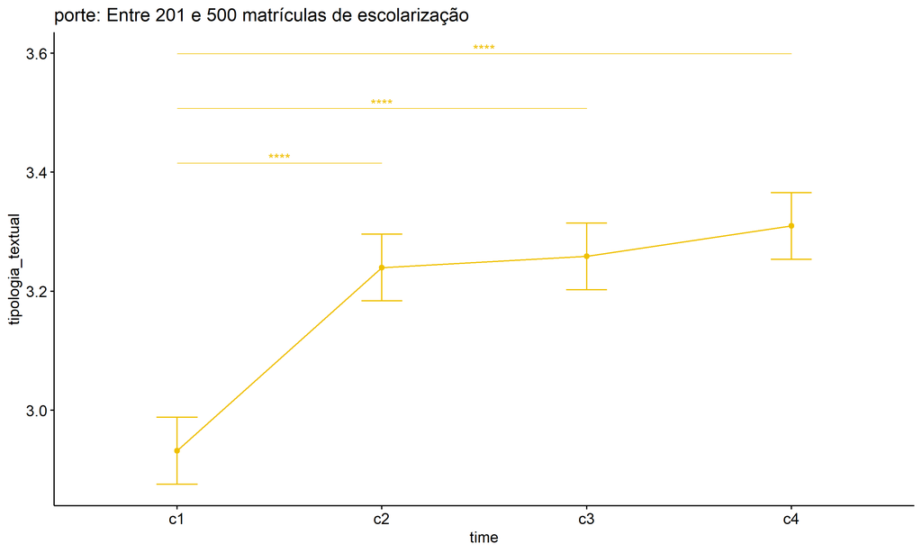

```r
if (length(non.ids) > 0) {
  emms.gg <- emms2[which(emms2$porte == "Entre 201 e 500 matrículas de escolarização"),]
  if (nrow(emms.gg) > 0)
    ggline(emms.gg, x = "time", y = "emmean", color = "#EFC000FF", ylab = "tipologia_textual") +
    geom_errorbar(aes(ymin = conf.low, ymax = conf.high),
                  width = 0.2, color = "#EFC000FF") +
    stat_pvalue_manual(
      add_xy_position(pwc[which(pwc$porte == "Entre 201 e 500 matrículas de escolarização"),],
                      x = "time", fun = "mean_se"),
      hide.ns = T, color = "#EFC000FF", tip.length = F) +
    labs(title = "porte: Entre 201 e 500 matrículas de escolarização") +
    theme(legend.text = element_blank())
}
```

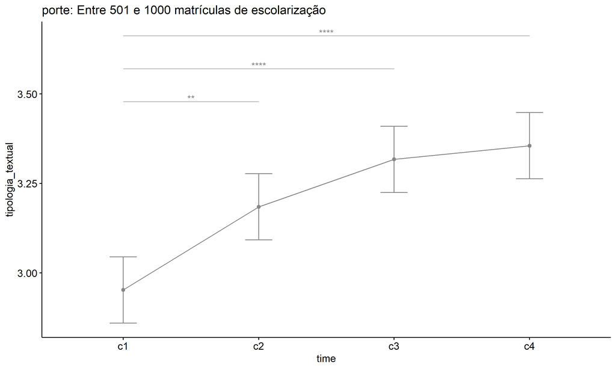

```r
if (length(non.ids) > 0) {
  emms.gg <- emms2[which(emms2$porte == "Entre 501 e 1000 matrículas de escolarização"),]
  if (nrow(emms.gg) > 0)
    ggline(emms.gg, x = "time", y = "emmean", color = "#868686FF", ylab = "tipologia_textual") +
    geom_errorbar(aes(ymin = conf.low, ymax = conf.high),
                  width = 0.2, color = "#868686FF") +
    stat_pvalue_manual(
      add_xy_position(pwc[which(pwc$porte == "Entre 501 e 1000 matrículas de escolarização"),],
                      x = "time", fun = "mean_se"),
      hide.ns = T, color = "#868686FF", tip.length = F) +
    labs(title = "porte: Entre 501 e 1000 matrículas de escolarização") +
    theme(legend.text = element_blank())
}
```

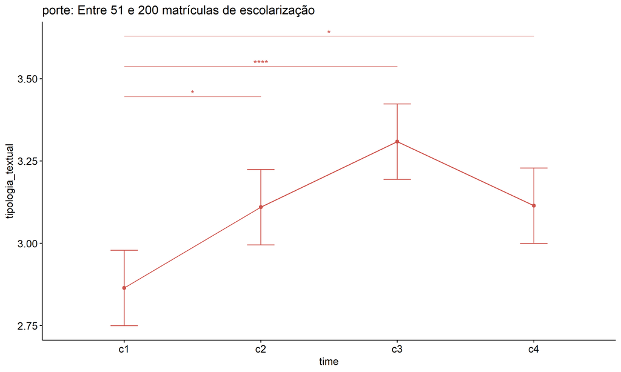

```r
if (length(non.ids) > 0) {
  emms.gg <- emms2[which(emms2$porte == "Entre 51 e 200 matrículas de escolarização"),]
  if (nrow(emms.gg) > 0)
    ggline(emms.gg, x = "time", y = "emmean", color = "#CD534CFF", ylab = "tipologia_textual") +
    geom_errorbar(aes(ymin = conf.low, ymax = conf.high),
                  width = 0.2, color = "#CD534CFF") +
    stat_pvalue_manual(
      add_xy_position(pwc[which(pwc$porte == "Entre 51 e 200 matrículas de escolarização"),],
                      x = "time", fun = "mean_se"),
      hide.ns = T, color = "#CD534CFF", tip.length = F) +
    labs(title = "porte: Entre 51 e 200 matrículas de escolarização") +
    theme(legend.text = element_blank())
}
```

```r
if (length(non.ids) > 0) {
  emms.gg <- emms2[which(emms2$porte == "Mais de 1000 matrículas de escolarização"),]
  if (nrow(emms.gg) > 0)
    ggline(emms.gg, x = "time", y = "emmean", color = "#7AA6DCFF", ylab = "tipologia_textual") +
    geom_errorbar(aes(ymin = conf.low, ymax = conf.high),
                  width = 0.2, color = "#7AA6DCFF") +
    stat_pvalue_manual(
      add_xy_position(pwc[which(pwc$porte == "Mais de 1000 matrículas de escolarização"),],
                      x = "time", fun = "mean_se"),
      hide.ns = T, color = "#7AA6DCFF", tip.length = F) +
    labs(title = "porte: Mais de 1000 matrículas de escolarização") +
    theme(legend.text = element_blank())
}
```

[output not shown]